# Analysen zur Vorbereitung des MZP 2

- Show All Code
- Hide All Code
- View Source

Kürzung der Tests

Author

Affiliation

Jürgen Schneider

DIPF

Published

August 19, 2024

# 1 Preparation

## 1.1 Import & wrangle data

```r
ALK_K4_MZP1 <- rio::import(here("data/ALK_K4_220324.sav"))
LAA_K4_MZP1 <- rio::import(here("data/LAA_MZP1_241023.csv"))
SAB_K4_MZP1 <- rio::import(here("data/SAB_K4_110324.sav"))
```

```r
############################################################################## #
##### KODIERUNG DER TPK ITEMS IN RICHTIG/FALSCH                             ####
##### (Bei LAA ist dies noch nicht codiert)                                    #
############################################################################## #


#### Skript 11a TPK-Test Kodierung ########################
LAA_K4_MZP1 <- LAA_K4_MZP1 |>
  mutate(
    tpksit1_2C = case_when(
      #Es wird ein Punkt vergeben, wenn die falsche Option NICHT ausgewählt wurde.
      is.na(TPKSIT1_2) ~ 1,
      TPKSIT1_2 == 1 ~ 0),
    tpksit1_3C = case_when(
      is.na(TPKSIT1_3) ~ 1,
      TPKSIT1_3 == 1 ~ 0),
    tpksit1_4C = case_when(
      is.na(TPKSIT1_4) ~ 1,
      TPKSIT1_4 == 1 ~ 0),
    tpksit1_5C = case_when(
      is.na(TPKSIT1_5) ~ 1,
      TPKSIT1_5 == 1 ~ 0),
    tpksit1_7C = case_when(
      is.na(TPKSIT1_7) ~ 1,
      TPKSIT1_7 == 1 ~ 0),
    tpksit1_8C = case_when(
      is.na(TPKSIT1_8) ~ 1,
      TPKSIT1_8 == 1 ~ 0),
    tpksit1_1C = case_when(
      #Es wird ein Punkt vergeben, wenn die richtige Option ausgewählt wurde.
      TPKSIT1_1 == 1 ~ 1,
      is.na(TPKSIT1_1) ~ 0),
    tpksit1_6C = case_when(
      TPKSIT1_6 == 1 ~ 1,
      is.na(TPKSIT1_6) ~ 0),

    tpksit9_1C = case_when(
      is.na(TPKSIT9_1) ~ 1,
      TPKSIT9_1 == 1 ~ 0),
    tpksit9_2C = case_when(
      is.na(TPKSIT9_2) ~ 1,
      TPKSIT9_2 == 1 ~ 0),
    tpksit9_3C = case_when(
      is.na(TPKSIT9_3) ~ 1,
      TPKSIT9_3 == 1 ~ 0),
    tpksit9_4C = case_when(
      is.na(TPKSIT9_4) ~ 1,
      TPKSIT9_4 == 1 ~ 0),
    tpksit9_7C = case_when(
      is.na(TPKSIT9_7) ~ 1,
      TPKSIT9_7 == 1 ~ 0),
    tpksit9_5C = case_when(
      TPKSIT9_5 == 1 ~ 1,
      is.na(TPKSIT9_5) ~ 0),
    tpksit9_6C = case_when(
      TPKSIT9_6 == 1 ~ 1,
      is.na(TPKSIT9_6) ~ 0),
    tpksit9_8C = case_when(
      TPKSIT9_8 == 1 ~ 1,
      is.na(TPKSIT9_8) ~ 0))
#Codierung des TPK-Tests.


# Subskala Situatives TPK Audio-Visuelle Technologie #####################
LAA_K4_MZP1 <- LAA_K4_MZP1 |>
  mutate(
    tpksit4_2C = case_when(
      is.na(TPKSIT4_2) ~ 1,
      TPKSIT4_2 == 1 ~ 0),
    tpksit4_3C = case_when(
      is.na(TPKSIT4_3) ~ 1,
      TPKSIT4_3 == 1 ~ 0),
    tpksit4_5C = case_when(
      is.na(TPKSIT4_5) ~ 1,
      TPKSIT4_5 == 1 ~ 0),
    tpksit4_6C = case_when(
      is.na(TPKSIT4_6) ~ 1,
      TPKSIT4_6 == 1 ~ 0),
    tpksit4_7C = case_when(
      is.na(TPKSIT4_7) ~ 1,
      TPKSIT4_7 == 1 ~ 0),
    tpksit4_8C = case_when(
      is.na(TPKSIT4_8) ~ 1,
      TPKSIT4_8 == 1 ~ 0),
    tpksit4_1C = case_when(
      TPKSIT4_1 == 1 ~ 1,
      is.na(TPKSIT4_1) ~ 0),
    tpksit4_4C = case_when(
      TPKSIT4_4 == 1 ~ 1,
      is.na(TPKSIT4_4) ~ 0),

    tpksit10_2C = case_when(
      is.na(TPKSIT10_2) ~ 1,
      TPKSIT10_2 == 1 ~ 0),
    tpksit10_3C = case_when(
      is.na(TPKSIT10_3) ~ 1,
      TPKSIT10_3 == 1 ~ 0),
    tpksit10_6C = case_when(
      is.na(TPKSIT10_6) ~ 1,
      TPKSIT10_6 == 1 ~ 0),
    tpksit10_7C = case_when(
      is.na(TPKSIT10_7) ~ 1,
      TPKSIT10_7 == 1 ~ 0),
    tpksit10_8C = case_when(
      is.na(TPKSIT10_8) ~ 1,
      TPKSIT10_8 == 1 ~ 0),
    tpksit10_1C = case_when(
      TPKSIT10_1 == 1 ~ 1,
      is.na(TPKSIT10_1) ~ 0),
    tpksit10_4C = case_when(
      TPKSIT10_4 == 1 ~ 1,
      is.na(TPKSIT10_4) ~ 0),
    tpksit10_5C = case_when(
      TPKSIT10_5 == 1 ~ 1,
      is.na(TPKSIT10_5) ~ 0),

    tpksit11_1C = case_when(
      is.na(TPKSIT11_1) ~ 1,
      TPKSIT11_1 == 1 ~ 0),
    tpksit11_2C = case_when(
      is.na(TPKSIT11_2) ~ 1,
      TPKSIT11_2 == 1 ~ 0),
    tpksit11_3C = case_when(
      is.na(TPKSIT11_3) ~ 1,
      TPKSIT11_3 == 1 ~ 0),
    tpksit11_4C = case_when(
      is.na(TPKSIT11_4) ~ 1,
      TPKSIT11_4 == 1 ~ 0),
    tpksit11_5C = case_when(
      is.na(TPKSIT11_5) ~ 1,
      TPKSIT11_5 == 1 ~ 0),
    tpksit11_7C = case_when(
      is.na(TPKSIT11_7) ~ 1,
      TPKSIT11_7 == 1 ~ 0),
    tpksit11_6C = case_when(
      TPKSIT11_6 == 1 ~ 1,
      is.na(TPKSIT11_6) ~ 0),
    tpksit11_8C = case_when(
      TPKSIT11_8 == 1 ~ 1,
      is.na(TPKSIT11_8) ~ 0),

    tpksit12_2C = case_when(
      is.na(TPKSIT12_2) ~ 1,
      TPKSIT12_2 == 1 ~ 0),
    tpksit12_4C = case_when(
      is.na(TPKSIT12_4) ~ 1,
      TPKSIT12_4 == 1 ~ 0),
    tpksit12_6C = case_when(
      is.na(TPKSIT12_6) ~ 1,
      TPKSIT12_6 == 1 ~ 0),
    tpksit12_7C = case_when(
      is.na(TPKSIT12_7) ~ 1,
      TPKSIT12_7 == 1 ~ 0),
    tpksit12_1C = case_when(
      TPKSIT12_1 == 1 ~ 1,
      is.na(TPKSIT12_1) ~ 0),
    tpksit12_3C = case_when(
      TPKSIT12_3 == 1 ~ 1,
      is.na(TPKSIT12_3) ~ 0),
    tpksit12_5C = case_when(
      TPKSIT12_5 == 1 ~ 1,
      is.na(TPKSIT12_5) ~ 0),
    tpksit12_8C = case_when(
      TPKSIT12_8 == 1 ~ 1,
      is.na(TPKSIT12_8) ~ 0))

# Subskala Situatives TPK Text-Basierende Technologie #####################
LAA_K4_MZP1 <- LAA_K4_MZP1 |>
  mutate(
    tpksit2_1C = case_when(
      is.na(TPKSIT2_1) ~ 1,
      TPKSIT2_1 == 1 ~ 0),
    tpksit2_3C = case_when(
      is.na(TPKSIT2_3) ~ 1,
      TPKSIT2_3 == 1 ~ 0),
    tpksit2_4C = case_when(
      is.na(TPKSIT2_4) ~ 1,
      TPKSIT2_4 == 1 ~ 0),
    tpksit2_7C = case_when(
      is.na(TPKSIT2_7) ~ 1,
      TPKSIT2_7 == 1 ~ 0),
    tpksit2_2C = case_when(
      TPKSIT2_2 == 1 ~ 1,
      is.na(TPKSIT2_2) ~ 0),
    tpksit2_5C = case_when(
      TPKSIT2_5 == 1 ~ 1,
      is.na(TPKSIT2_5) ~ 0),
    tpksit2_6C = case_when(
      TPKSIT2_6 == 1 ~ 1,
      is.na(TPKSIT2_6) ~ 0),
    tpksit2_8C = case_when(
      TPKSIT2_8 == 1 ~ 1,
      is.na(TPKSIT2_8) ~ 0),

    tpksit3_1C = case_when(
      is.na(TPKSIT3_1) ~ 1,
      TPKSIT3_1 == 1 ~ 0),
    tpksit3_4C = case_when(
      is.na(TPKSIT3_4) ~ 1,
      TPKSIT3_4 == 1 ~ 0),
    tpksit3_6C = case_when(
      is.na(TPKSIT3_6) ~ 1,
      TPKSIT3_6 == 1 ~ 0),
    tpksit3_7C = case_when(
      is.na(TPKSIT3_7) ~ 1,
      TPKSIT3_7 == 1 ~ 0),
    tpksit3_2C = case_when(
      TPKSIT3_2 == 1 ~ 1,
      is.na(TPKSIT3_2) ~ 0),
    tpksit3_3C = case_when(
      TPKSIT3_3 == 1 ~ 1,
      is.na(TPKSIT3_3) ~ 0),
    tpksit3_5C = case_when(
      TPKSIT3_5 == 1 ~ 1,
      is.na(TPKSIT3_5) ~ 0),
    tpksit3_8C = case_when(
      TPKSIT3_8 == 1 ~ 1,
      is.na(TPKSIT3_8) ~ 0),
```

```r
    tpksit7_1C = case_when(
      is.na(TPKSIT7_1) ~ 1,
      TPKSIT7_1 == 1 ~ 0),
    tpksit7_4C = case_when(
      is.na(TPKSIT7_4) ~ 1,
      TPKSIT7_4 == 1 ~ 0),
    tpksit7_6C = case_when(
      is.na(TPKSIT7_6) ~ 1,
      TPKSIT7_6 == 1 ~ 0),
    tpksit7_7C = case_when(
      is.na(TPKSIT7_7) ~ 1,
      TPKSIT7_7 == 1 ~ 0),
    tpksit7_2C = case_when(
      TPKSIT7_2 == 1 ~ 1,
      is.na(TPKSIT7_2) ~ 0),
    tpksit7_3C = case_when(
      TPKSIT7_3 == 1 ~ 1,
      is.na(TPKSIT7_3) ~ 0),
    tpksit7_5C = case_when(
      TPKSIT7_5 == 1 ~ 1,
      is.na(TPKSIT7_5) ~ 0),
    tpksit7_8C = case_when(
      TPKSIT7_8 == 1 ~ 1,
      is.na(TPKSIT7_8) ~ 0))

# Subskala Situatives TPK Adaptive-Assessment Technologie #####################
LAA_K4_MZP1 <- LAA_K4_MZP1 |>
  mutate(
    tpksit5_4C = case_when(
      is.na(TPKSIT5_4) ~ 1,
      TPKSIT5_4 == 1 ~ 0),
    tpksit5_5C = case_when(
      is.na(TPKSIT5_5) ~ 1,
      TPKSIT5_5 == 1 ~ 0),
    tpksit5_6C = case_when(
      is.na(TPKSIT5_6) ~ 1,
      TPKSIT5_6 == 1 ~ 0),
    tpksit5_7C = case_when(
      is.na(TPKSIT5_7) ~ 1,
      TPKSIT5_7 == 1 ~ 0),
    tpksit5_1C = case_when(
      TPKSIT5_1 == 1 ~ 1,
      is.na(TPKSIT5_1) ~ 0),
    tpksit5_2C = case_when(
      TPKSIT5_2 == 1 ~ 1,
      is.na(TPKSIT5_2) ~ 0),
    tpksit5_3C = case_when(
      TPKSIT5_3 == 1 ~ 1,
      is.na(TPKSIT5_3) ~ 0),
    tpksit5_8C = case_when(
      TPKSIT5_8 == 1 ~ 1,
      is.na(TPKSIT5_8) ~ 0),

    tpksit6_1C = case_when(
      is.na(TPKSIT6_1) ~ 1,
      TPKSIT6_1 == 1 ~ 0),
    tpksit6_6C = case_when(
      is.na(TPKSIT6_6) ~ 1,
      TPKSIT6_6 == 1 ~ 0),
    tpksit6_7C = case_when(
      is.na(TPKSIT6_7) ~ 1,
      TPKSIT6_7 == 1 ~ 0),
    tpksit6_8C = case_when(
      is.na(TPKSIT6_8) ~ 1,
      TPKSIT6_8 == 1 ~ 0),
    tpksit6_2C = case_when(
      TPKSIT6_2 == 1 ~ 1,
      is.na(TPKSIT6_2) ~ 0),
    tpksit6_3C = case_when(
      TPKSIT6_3 == 1 ~ 1,
      is.na(TPKSIT6_3) ~ 0),
    tpksit6_4C = case_when(
      TPKSIT6_4 == 1 ~ 1,
      is.na(TPKSIT6_4) ~ 0),
    tpksit6_5C = case_when(
      TPKSIT6_5 == 1 ~ 1,
      is.na(TPKSIT6_5) ~ 0),

    tpksit8_2C = case_when(
      is.na(TPKSIT8_2) ~ 1,
      TPKSIT8_2 == 1 ~ 0),
    tpksit8_4C = case_when(
      is.na(TPKSIT8_4) ~ 1,
      TPKSIT8_4 == 1 ~ 0),
    tpksit8_5C = case_when(
      is.na(TPKSIT8_5) ~ 1,
      TPKSIT8_5 == 1 ~ 0),
    tpksit8_6C = case_when(
      is.na(TPKSIT8_6) ~ 1,
      TPKSIT8_6 == 1 ~ 0),
    tpksit8_8C = case_when(
      is.na(TPKSIT8_8) ~ 1,
      TPKSIT8_8 == 1 ~ 0),
    tpksit8_1C = case_when(
      TPKSIT8_1 == 1 ~ 1,
      is.na(TPKSIT8_1) ~ 0),
    tpksit8_3C = case_when(
      TPKSIT8_3 == 1 ~ 1,
      is.na(TPKSIT8_3) ~ 0),
    tpksit8_7C = case_when(
      TPKSIT8_7 == 1 ~ 1,
      is.na(TPKSIT8_7) ~ 0))

# Subskala Konzeptuelles TPK Potentiale #####################
LAA_K4_MZP1 <- LAA_K4_MZP1 |>
  mutate(
    tpkpot1_1C = case_when(
      is.na(TPKPOT1_1) ~ 1,
      TPKPOT1_1 == 1 ~ 0),
    tpkpot1_3C = case_when(
      is.na(TPKPOT1_3) ~ 1,
      TPKPOT1_3 == 1 ~ 0),
    tpkpot1_2C = case_when(
      TPKPOT1_2 == 1 ~ 1,
      is.na(TPKPOT1_2) ~ 0),
    tpkpot1_4C = case_when(
      TPKPOT1_4 == 1 ~ 1,
      is.na(TPKPOT1_4) ~ 0),

    tpkpot2_2C = case_when(
      is.na(TPKPOT2_2) ~ 1,
      TPKPOT2_2 == 1 ~ 0),
    tpkpot2_1C = case_when(
      TPKPOT2_1 == 1 ~ 1,
      is.na(TPKPOT2_1) ~ 0),
    tpkpot2_3C = case_when(
      TPKPOT2_3 == 1 ~ 1,
      is.na(TPKPOT2_3) ~ 0),
    tpkpot2_4C = case_when(
      TPKPOT2_4 == 1 ~ 1,
      is.na(TPKPOT2_4) ~ 0),

    tpkpot3_1C = case_when(
      is.na(TPKPOT3_1) ~ 1,
      TPKPOT3_1 == 1 ~ 0),
    tpkpot3_3C = case_when(
      is.na(TPKPOT3_3) ~ 1,
      TPKPOT3_3 == 1 ~ 0),
    tpkpot3_2C = case_when(
      TPKPOT3_2 == 1 ~ 1,
      is.na(TPKPOT3_2) ~ 0),
    tpkpot3_4C = case_when(
      TPKPOT3_4 == 1 ~ 1,
      is.na(TPKPOT3_4) ~ 0),

    tpkpot4_3C = case_when(
      is.na(TPKPOT4_3) ~ 1,
      TPKPOT4_3 == 1 ~ 0),
    tpkpot4_4C = case_when(
      is.na(TPKPOT4_4) ~ 1,
      TPKPOT4_4 == 1 ~ 0),
    tpkpot4_1C = case_when(
      TPKPOT4_1 == 1 ~ 1,
      is.na(TPKPOT4_1) ~ 0),
    tpkpot4_2C = case_when(
      TPKPOT4_2 == 1 ~ 1,
      is.na(TPKPOT4_2) ~ 0),

    tpkpot5_1C = case_when(
      is.na(TPKPOT5_1) ~ 1,
      TPKPOT5_1 == 1 ~ 0),
    tpkpot5_4C = case_when(
      is.na(TPKPOT5_4) ~ 1,
      TPKPOT5_4 == 1 ~ 0),
    tpkpot5_2C = case_when(
      TPKPOT5_2 == 1 ~ 1,
      is.na(TPKPOT5_2) ~ 0),
    tpkpot5_3C = case_when(
      TPKPOT5_3 == 1 ~ 1,
      is.na(TPKPOT5_3) ~ 0))

# Subskala Konzeptuelles TPK Prinzipien #####################
LAA_K4_MZP1 <- LAA_K4_MZP1 |>
  mutate(
    tpksup1_1C = case_when(
      is.na(TPKSUP1_1) ~ 1,
      TPKSUP1_1 == 1 ~ 0),
    tpksup1_3C = case_when(
      is.na(TPKSUP1_3) ~ 1,
      TPKSUP1_3 == 1 ~ 0),
    tpksup1_4C = case_when(
      is.na(TPKSUP1_4) ~ 1,
      TPKSUP1_4 == 1 ~ 0),
    tpksup1_2C = case_when(
      TPKSUP1_2 == 1 ~ 1,
      is.na(TPKSUP1_2) ~ 0),

    tpksup2_3C = case_when(
      is.na(TPKSUP2_3) ~ 1,
      TPKSUP2_3 == 1 ~ 0),
    tpksup2_4C = case_when(
      is.na(TPKSUP2_4) ~ 1,
      TPKSUP2_4 == 1 ~ 0),
    tpksup2_1C = case_when(
      TPKSUP2_1 == 1 ~ 1,
      is.na(TPKSUP2_1) ~ 0),
    tpksup2_2C = case_when(
      TPKSUP2_2 == 1 ~ 1,
      is.na(TPKSUP2_2) ~ 0),

    tpksup3_1C = case_when(
      is.na(TPKSUP3_1) ~ 1,
      TPKSUP3_1 == 1 ~ 0),
    tpksup3_3C = case_when(
      is.na(TPKSUP3_3) ~ 1,
      TPKSUP3_3 == 1 ~ 0),
    tpksup3_2C = case_when(
      TPKSUP3_2 == 1 ~ 1,
      is.na(TPKSUP3_2) ~ 0),
    tpksup3_4C = case_when(
      TPKSUP3_4 == 1 ~ 1,
      is.na(TPKSUP3_4) ~ 0))


#### Skript 11b TPK_Test Auswertung #########################
LAA_K4_MZP1 <- LAA_K4_MZP1 |>
  mutate(
    #Berechnung der Scores für die Subskalen & die Gesamtskala des situationalen TPK.
    tpksit_score_av = (tpksit4_1C + tpksit4_2C + tpksit4_3C + tpksit4_4C + tpksit4_5C +
                       tpksit4_6C + tpksit4_7C + tpksit4_8C + tpksit10_1C +
                       tpksit10_2C + tpksit10_3C + tpksit10_4C + tpksit10_5C +
                       tpksit10_6C + tpksit10_7C + tpksit10_8C + tpksit11_1C +
                       tpksit11_2C + tpksit11_3C + tpksit11_4C + tpksit11_5C +
                       tpksit11_6C + tpksit11_7C + tpksit11_8C + tpksit12_1C +
                       tpksit12_2C + tpksit12_3C + tpksit12_4C + tpksit12_5C +
                       tpksit12_6C + tpksit12_7C + tpksit12_8C) / 32 *100,
```

```r
    tpksit_score_tb = (tpksit2_1C + tpksit2_2C + tpksit2_3C + tpksit2_4C +
                       tpksit2_5C + tpksit2_6C + tpksit2_7C + tpksit2_8C +
                       tpksit3_1C + tpksit3_2C + tpksit3_3C + tpksit3_4C +
                       tpksit3_5C + tpksit3_6C + tpksit3_7C + tpksit3_8C +
                       tpksit7_1C + tpksit7_2C + tpksit7_3C + tpksit7_4C +
                       tpksit7_5C + tpksit7_6C + tpksit7_7C + tpksit7_8C) /24 *100,

    tpksit_score_aa = (tpksit5_1C + tpksit5_2C + tpksit5_3C + tpksit5_4C +
                       tpksit5_5C + tpksit5_6C + tpksit5_7C + tpksit5_8C +
                       tpksit6_1C + tpksit6_2C + tpksit6_3C + tpksit6_4C +
                       tpksit6_5C + tpksit6_6C + tpksit6_7C + tpksit6_8C +
                       tpksit8_1C + tpksit8_2C + tpksit8_3C + tpksit8_4C +
                       tpksit8_5C + tpksit8_6C + tpksit8_7C + tpksit8_8C) /24 *100,

    tpksit_score = (tpksit2_1C + tpksit2_2C + tpksit2_3C + tpksit2_4C +
                    tpksit2_5C + tpksit2_6C + tpksit2_7C + tpksit2_8C +
                    tpksit3_1C + tpksit3_2C + tpksit3_3C + tpksit3_4C +
                    tpksit3_5C + tpksit3_6C + tpksit3_7C + tpksit3_8C +
                    tpksit4_1C + tpksit4_2C + tpksit4_3C + tpksit4_4C +
                    tpksit4_5C + tpksit4_6C + tpksit4_7C + tpksit4_8C +
                    tpksit5_1C + tpksit5_2C + tpksit5_3C + tpksit5_4C +
                    tpksit5_5C + tpksit5_6C + tpksit5_7C + tpksit5_8C +
                    tpksit6_1C + tpksit6_2C + tpksit6_3C + tpksit6_4C +
                    tpksit6_5C + tpksit6_6C + tpksit6_7C + tpksit6_8C +
                    tpksit7_1C + tpksit7_2C + tpksit7_3C + tpksit7_4C +
                    tpksit7_5C + tpksit7_6C + tpksit7_7C + tpksit7_8C +
                    tpksit8_1C + tpksit8_2C + tpksit8_3C + tpksit8_4C +
                    tpksit8_5C + tpksit8_6C + tpksit8_7C + tpksit8_8C +
                    tpksit10_1C + tpksit10_2C + tpksit10_3C + tpksit10_4C +
                    tpksit10_5C + tpksit10_6C + tpksit10_7C + tpksit10_8C +
                    tpksit11_1C + tpksit11_2C + tpksit11_3C + tpksit11_4C +
                    tpksit11_5C + tpksit11_6C + tpksit11_7C + tpksit11_8C +
                    tpksit12_1C + tpksit12_2C + tpksit12_3C + tpksit12_4C +
                    tpksit12_5C + tpksit12_6C + tpksit12_7C + tpksit12_8C) /80 *100)

LAA_K4_MZP1 <- LAA_K4_MZP1 |>
  mutate(
    #Berechnung der Scores für Subskalen & die Gesamtskala des konzeptuellen TPK.
    tpkpot_score = (tpkpot1_1C + tpkpot1_2C + tpkpot1_3C + tpkpot1_4C +
                    tpkpot2_1C + tpkpot2_2C + tpkpot2_3C + tpkpot2_4C +
                    tpkpot3_1C + tpkpot3_2C + tpkpot3_3C + tpkpot3_4C +
                    tpkpot4_1C + tpkpot4_2C + tpkpot4_3C + tpkpot4_4C +
                    tpkpot5_1C + tpkpot5_2C + tpkpot5_3C + tpkpot5_4C) /20 *100,

    tpksup_score = (tpksup1_1C + tpksup1_2C + tpksup1_3C + tpksup1_4C +
                    tpksup2_1C + tpksup2_2C + tpksup2_3C + tpksup2_4C +
                    tpksup3_1C + tpksup3_2C + tpksup3_3C + tpksup3_4C) /12 *100,

    tpkcon_score = (tpkpot1_1C + tpkpot1_2C + tpkpot1_3C + tpkpot1_4C +
                    tpkpot2_1C + tpkpot2_2C + tpkpot2_3C + tpkpot2_4C +
                    tpkpot3_1C + tpkpot3_2C + tpkpot3_3C + tpkpot3_4C +
                    tpkpot4_1C + tpkpot4_2C + tpkpot4_3C + tpkpot4_4C +
                    tpkpot5_1C + tpkpot5_2C + tpkpot5_3C + tpkpot5_4C +
                    tpksup1_1C + tpksup1_2C + tpksup1_3C + tpksup1_4C +
                    tpksup2_1C + tpksup2_2C + tpksup2_3C + tpksup2_4C +
                    tpksup3_1C + tpksup3_2C + tpksup3_3C + tpksup3_4C) /32 *100)
```

```r
############################################################################## #
##### BILDUNG EINES SCORES JE ITEM                                          ####
############################################################################## #

## LAA ####################################################################### #

LAA_K4_MZP1 <- LAA_K4_MZP1 %>%
  mutate(
        # tpksit1 = rowMeans(data.frame(tpksit1_1C, tpksit1_2C,
        #                                tpksit1_3C, tpksit1_4C,
        #                                tpksit1_5C, tpksit1_6C,
        #                                tpksit1_7C, tpksit1_8C),
        #                     na.rm = T),
         tpksit2 = rowMeans(data.frame(tpksit2_1C, tpksit2_2C,
                                       tpksit2_3C, tpksit2_4C,
                                       tpksit2_5C, tpksit2_6C,
                                       tpksit2_7C, tpksit2_8C),
                            na.rm = T),
         tpksit3 = rowMeans(data.frame(tpksit3_1C, tpksit3_2C,
                                       tpksit3_3C, tpksit3_4C,
                                       tpksit3_5C, tpksit3_6C,
                                       tpksit3_7C, tpksit3_8C),
                            na.rm = T),
         tpksit4 = rowMeans(data.frame(tpksit4_1C, tpksit4_2C,
                                       tpksit4_3C, tpksit4_4C,
                                       tpksit4_5C, tpksit4_6C,
                                       tpksit4_7C, tpksit4_8C),
                            na.rm = T),
         tpksit5 = rowMeans(data.frame(tpksit5_1C, tpksit5_2C,
                                       tpksit5_3C, tpksit5_4C,
                                       tpksit5_5C, tpksit5_6C,
                                       tpksit5_7C, tpksit5_8C),
                            na.rm = T),
         tpksit6 = rowMeans(data.frame(tpksit6_1C, tpksit6_2C,
                                       tpksit6_3C, tpksit6_4C,
                                       tpksit6_5C, tpksit6_6C,
                                       tpksit6_7C, tpksit6_8C),
                            na.rm = T),
         tpksit7 = rowMeans(data.frame(tpksit7_1C, tpksit7_2C,
                                       tpksit7_3C, tpksit7_4C,
                                       tpksit7_5C, tpksit7_6C,
                                       tpksit7_7C, tpksit7_8C),
                            na.rm = T),
         tpksit8 = rowMeans(data.frame(tpksit8_1C, tpksit8_2C,
                                       tpksit8_3C, tpksit8_4C,
                                       tpksit8_5C, tpksit8_6C,
                                       tpksit8_7C, tpksit8_8C),
                            na.rm = T),
         tpksit10 = rowMeans(data.frame(tpksit10_1C, tpksit10_2C,
                                        tpksit10_3C, tpksit10_4C,
                                        tpksit10_5C, tpksit10_6C,
                                        tpksit10_7C, tpksit10_8C),
                            na.rm = T),
         tpksit11 = rowMeans(data.frame(tpksit11_1C, tpksit11_2C,
                                        tpksit11_3C, tpksit11_4C,
                                        tpksit11_5C, tpksit11_6C,
                                        tpksit11_7C, tpksit11_8C),
                            na.rm = T),
         tpksit12 = rowMeans(data.frame(tpksit12_1C, tpksit12_2C,
                                        tpksit12_3C, tpksit12_4C,
                                        tpksit12_5C, tpksit12_6C,
                                        tpksit12_7C, tpksit12_8C),
                            na.rm = T),
         tpkpot1 = rowMeans(data.frame(tpkpot1_1C, tpkpot1_2C,
                                       tpkpot1_3C, tpkpot1_4C ),
                            na.rm = T),
         tpkpot2 = rowMeans(data.frame(tpkpot2_1C, tpkpot2_2C,
                                        tpkpot2_3C, tpkpot2_4C ),
                            na.rm = T),
         tpkpot3 = rowMeans(data.frame(tpkpot3_1C, tpkpot3_2C,
                                        tpkpot3_3C, tpkpot3_4C),
                            na.rm = T),
         tpkpot4 = rowMeans(data.frame(tpkpot4_1C, tpkpot4_2C,
                                        tpkpot4_3C, tpkpot4_4C),
                            na.rm = T),
         tpkpot5 = rowMeans(data.frame(tpkpot5_1C, tpkpot5_2C,
                                        tpkpot5_3C, tpkpot5_4C),
                            na.rm = T),
         tpksup1 = rowMeans(data.frame(tpksup1_1C, tpksup1_2C,
                                        tpksup1_3C, tpksup1_4C),
                            na.rm = T),
         tpksup2 = rowMeans(data.frame(tpksup2_1C, tpksup2_2C,
                                        tpksup2_3C, tpksup2_4C),
                            na.rm = T),
         tpksup3 = rowMeans(data.frame(tpksup3_1C, tpksup3_2C,
                                        tpksup3_3C, tpksup3_4C),
                            na.rm = T))



## ALK ####################################################################### #

ALK_K4_MZP1 <- ALK_K4_MZP1 %>%
  mutate(tpksit2 = rowMeans(data.frame(tpksit2_1c_01K4, tpksit2_2c_01K4,
                                       tpksit2_3c_01K4, tpksit2_4c_01K4,
                                       tpksit2_5c_01K4, tpksit2_6c_01K4,
                                       tpksit2_7c_01K4, tpksit2_8c_01K4),
                            na.rm = T),
         tpksit3 = rowMeans(data.frame(tpksit3_1c_01K4, tpksit3_2c_01K4,
                                       tpksit3_3c_01K4, tpksit3_4c_01K4,
                                       tpksit3_5c_01K4, tpksit3_6c_01K4,
                                       tpksit3_7c_01K4, tpksit3_8c_01K4),
                            na.rm = T),
         tpksit4 = rowMeans(data.frame(tpksit4_1c_01K4, tpksit4_2c_01K4,
                                       tpksit4_3c_01K4, tpksit4_4c_01K4,
                                       tpksit4_5c_01K4, tpksit4_6c_01K4,
                                       tpksit4_7c_01K4, tpksit4_8c_01K4),
                            na.rm = T),
         tpksit5 = rowMeans(data.frame(tpksit5_1c_01K4, tpksit5_2c_01K4,
                                       tpksit5_3c_01K4, tpksit5_4c_01K4,
                                       tpksit5_5c_01K4, tpksit5_6c_01K4,
                                       tpksit5_7c_01K4, tpksit5_8c_01K4),
                            na.rm = T),
         tpksit6 = rowMeans(data.frame(tpksit6_1c_01K4, tpksit6_2c_01K4,
                                       tpksit6_3c_01K4, tpksit6_4c_01K4,
                                       tpksit6_5c_01K4, tpksit6_6c_01K4,
                                       tpksit6_7c_01K4, tpksit6_8c_01K4),
                            na.rm = T),
         tpksit7 = rowMeans(data.frame(tpksit7_1c_01K4, tpksit7_2c_01K4,
                                       tpksit7_3c_01K4, tpksit7_4c_01K4,
                                       tpksit7_5c_01K4, tpksit7_6c_01K4,
                                       tpksit7_7c_01K4, tpksit7_8c_01K4),
                            na.rm = T),
         tpksit8 = rowMeans(data.frame(tpksit8_1c_01K4, tpksit8_2c_01K4,
                                       tpksit8_3c_01K4, tpksit8_4c_01K4,
                                       tpksit8_5c_01K4, tpksit8_6c_01K4,
                                       tpksit8_7c_01K4, tpksit8_8c_01K4),
                            na.rm = T),
         tpksit10 = rowMeans(data.frame(tpksit10_1c_01K4, tpksit10_2c_01K4,
                                        tpksit10_3c_01K4, tpksit10_4c_01K4,
                                        tpksit10_5c_01K4, tpksit10_6c_01K4,
                                        tpksit10_7c_01K4, tpksit10_8c_01K4),
                            na.rm = T),
         tpksit11 = rowMeans(data.frame(tpksit11_1c_01K4, tpksit11_2c_01K4,
                                        tpksit11_3c_01K4, tpksit11_4c_01K4,
                                        tpksit11_5c_01K4, tpksit11_6c_01K4,
                                        tpksit11_7c_01K4, tpksit11_8c_01K4),
                            na.rm = T),
         tpksit12 = rowMeans(data.frame(tpksit12_1c_01K4, tpksit12_2c_01K4,
                                        tpksit12_3c_01K4, tpksit12_4c_01K4,
                                        tpksit12_5c_01K4, tpksit12_6c_01K4,
                                        tpksit12_7c_01K4, tpksit12_8c_01K4),
                            na.rm = T),
         tpkpot1 = rowMeans(data.frame(tpkpot1_1c_01K4, tpkpot1_2c_01K4,
                                       tpkpot1_3c_01K4, tpkpot1_4c_01K4 ),
                            na.rm = T),
         tpkpot2 = rowMeans(data.frame(tpkpot2_1c_01K4, tpkpot2_2c_01K4,
                                        tpkpot2_3c_01K4, tpkpot2_4c_01K4 ),
                            na.rm = T),
         tpkpot3 = rowMeans(data.frame(tpkpot3_1c_01K4, tpkpot3_2c_01K4,
                                        tpkpot3_3c_01K4, tpkpot3_4c_01K4),
                            na.rm = T),
         tpkpot4 = rowMeans(data.frame(tpkpot4_1c_01K4, tpkpot4_2c_01K4,
                                        tpkpot4_3c_01K4, tpkpot4_4c_01K4),
                            na.rm = T),
         tpkpot5 = rowMeans(data.frame(tpkpot5_1c_01K4, tpkpot5_2c_01K4,
                                        tpkpot5_3c_01K4, tpkpot5_4c_01K4),
                            na.rm = T),
         tpksup1 = rowMeans(data.frame(tpksup1_1c_01K4, tpksup1_2c_01K4,
                                        tpksup1_3c_01K4, tpksup1_4c_01K4),
                            na.rm = T),
         tpksup2 = rowMeans(data.frame(tpksup2_1c_01K4, tpksup2_2c_01K4,
                                        tpksup2_3c_01K4, tpksup2_4c_01K4),
                            na.rm = T),
         tpksup3 = rowMeans(data.frame(tpksup3_1c_01K4, tpksup3_2c_01K4,
                                        tpksup3_3c_01K4, tpksup3_4c_01K4),
                            na.rm = T))
```

```r
## SAB ####################################################################### #

SAB_K4_MZP1 <- SAB_K4_MZP1 %>%
  mutate(tpksit2 = rowMeans(data.frame(tpksit2_1c_01K4, tpksit2_2c_01K4,
                                       tpksit2_3c_01K4, tpksit2_4c_01K4,
                                       tpksit2_5c_01K4, tpksit2_6c_01K4,
                                       tpksit2_7c_01K4, tpksit2_8c_01K4),
                            na.rm = T),
         tpksit3 = rowMeans(data.frame(tpksit3_1c_01K4, tpksit3_2c_01K4,
                                       tpksit3_3c_01K4, tpksit3_4c_01K4,
                                       tpksit3_5c_01K4, tpksit3_6c_01K4,
                                       tpksit3_7c_01K4, tpksit3_8c_01K4),
                            na.rm = T),
         tpksit4 = rowMeans(data.frame(tpksit4_1c_01K4, tpksit4_2c_01K4,
                                       tpksit4_3c_01K4, tpksit4_4c_01K4,
                                       tpksit4_5c_01K4, tpksit4_6c_01K4,
                                       tpksit4_7c_01K4, tpksit4_8c_01K4),
                            na.rm = T),
         tpksit5 = rowMeans(data.frame(tpksit5_1c_01K4, tpksit5_2c_01K4,
                                       tpksit5_3c_01K4, tpksit5_4c_01K4,
                                       tpksit5_5c_01K4, tpksit5_6c_01K4,
                                       tpksit5_7c_01K4, tpksit5_8c_01K4),
                            na.rm = T),
         tpksit6 = rowMeans(data.frame(tpksit6_1c_01K4, tpksit6_2c_01K4,
                                       tpksit6_3c_01K4, tpksit6_4c_01K4,
                                       tpksit6_5c_01K4, tpksit6_6c_01K4,
                                       tpksit6_7c_01K4, tpksit6_8c_01K4),
                            na.rm = T),
         tpksit7 = rowMeans(data.frame(tpksit7_1c_01K4, tpksit7_2c_01K4,
                                       tpksit7_3c_01K4, tpksit7_4c_01K4,
                                       tpksit7_5c_01K4, tpksit7_6c_01K4,
                                       tpksit7_7c_01K4, tpksit7_8c_01K4),
                            na.rm = T),
         tpksit8 = rowMeans(data.frame(tpksit8_1c_01K4, tpksit8_2c_01K4,
                                       tpksit8_3c_01K4, tpksit8_4c_01K4,
                                       tpksit8_5c_01K4, tpksit8_6c_01K4,
                                       tpksit8_7c_01K4, tpksit8_8c_01K4),
                            na.rm = T),
         tpksit10 = rowMeans(data.frame(tpksit10_1c_01K4, tpksit10_2c_01K4,
                                        tpksit10_3c_01K4, tpksit10_4c_01K4,
                                        tpksit10_5c_01K4, tpksit10_6c_01K4,
                                        tpksit10_7c_01K4, tpksit10_8c_01K4),
                            na.rm = T),
         tpksit11 = rowMeans(data.frame(tpksit11_1c_01K4, tpksit11_2c_01K4,
                                        tpksit11_3c_01K4, tpksit11_4c_01K4,
                                        tpksit11_5c_01K4, tpksit11_6c_01K4,
                                        tpksit11_7c_01K4, tpksit11_8c_01K4),
                            na.rm = T),
         tpksit12 = rowMeans(data.frame(tpksit12_1c_01K4, tpksit12_2c_01K4,
                                        tpksit12_3c_01K4, tpksit12_4c_01K4,
                                        tpksit12_5c_01K4, tpksit12_6c_01K4,
                                        tpksit12_7c_01K4, tpksit12_8c_01K4),
                            na.rm = T),
         tpkpot1 = rowMeans(data.frame(tpkpot1_1c_01K4, tpkpot1_2c_01K4,
                                       tpkpot1_3c_01K4, tpkpot1_4c_01K4 ),
                            na.rm = T),
         tpkpot2 = rowMeans(data.frame(tpkpot2_1c_01K4, tpkpot2_2c_01K4,
                                        tpkpot2_3c_01K4, tpkpot2_4c_01K4 ),
                            na.rm = T),
         tpkpot3 = rowMeans(data.frame(tpkpot3_1c_01K4, tpkpot3_2c_01K4,
                                        tpkpot3_3c_01K4, tpkpot3_4c_01K4),
                            na.rm = T),
         tpkpot4 = rowMeans(data.frame(tpkpot4_1c_01K4, tpkpot4_2c_01K4,
                                        tpkpot4_3c_01K4, tpkpot4_4c_01K4),
                            na.rm = T),
         tpkpot5 = rowMeans(data.frame(tpkpot5_1c_01K4, tpkpot5_2c_01K4,
                                        tpkpot5_3c_01K4, tpkpot5_4c_01K4),
                            na.rm = T),
         tpksup1 = rowMeans(data.frame(tpksup1_1c_01K4, tpksup1_2c_01K4,
                                        tpksup1_3c_01K4, tpksup1_4c_01K4),
                            na.rm = T),
         tpksup2 = rowMeans(data.frame(tpksup2_1c_01K4, tpksup2_2c_01K4,
                                        tpksup2_3c_01K4, tpksup2_4c_01K4),
                            na.rm = T),
         tpksup3 = rowMeans(data.frame(tpksup3_1c_01K4, tpksup3_2c_01K4,
                                        tpksup3_3c_01K4, tpksup3_4c_01K4),
                            na.rm = T))
```

# 2 Sit-Factor

**Reliability**

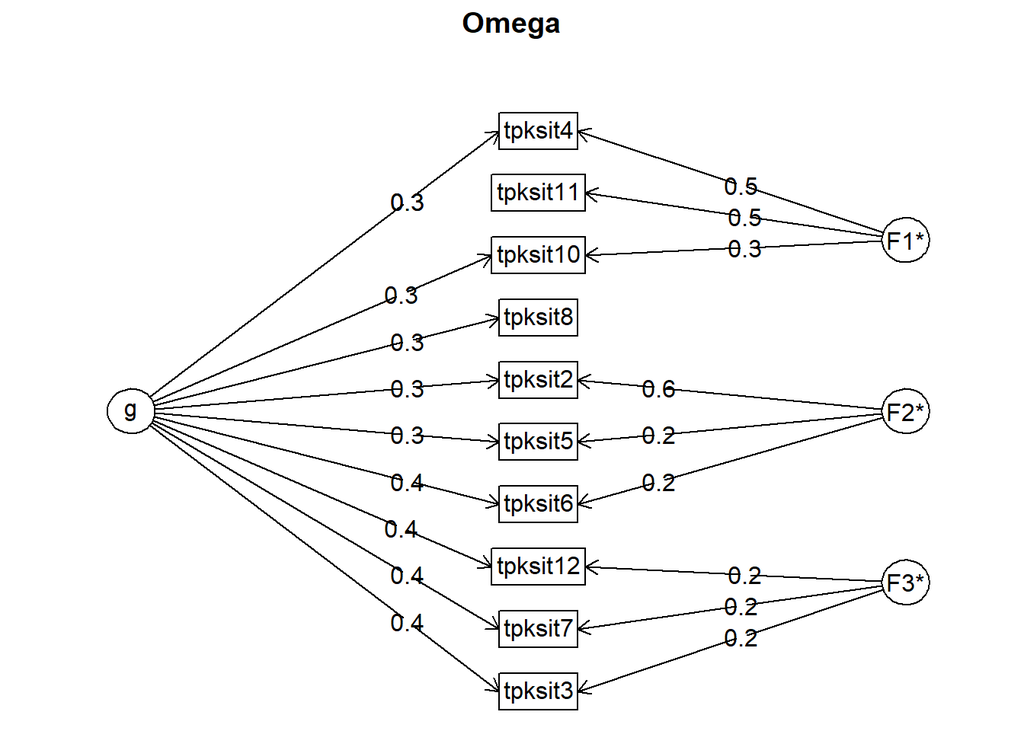

```
Omega
Call: omegah(m = m, nfactors = nfactors, fm = fm, key = key, flip = flip,
    digits = digits, title = title, sl = sl, labels = labels,
    plot = plot, n.obs = n.obs, rotate = rotate, Phi = Phi, option = option,
    covar = covar)
Alpha:                 0.63
G.6:                   0.62
Omega Hierarchical:    0.44
Omega H asymptotic:    0.66
Omega Total            0.67

Schmid Leiman Factor loadings greater than  0.2
             g   F1*   F2*   F3*   h2   u2   p2
tpksit2   0.29        0.57       0.41 0.59 0.20
tpksit3   0.40              0.21 0.23 0.77 0.71
tpksit4   0.29  0.54             0.38 0.62 0.23
tpksit5   0.27        0.23       0.13 0.87 0.55
tpksit6   0.42        0.22       0.28 0.72 0.64
tpksit7   0.44              0.23 0.25 0.75 0.77
tpksit8   0.29                   0.13 0.87 0.63
tpksit10  0.25  0.31             0.17 0.83 0.38
tpksit11        0.52             0.31 0.69 0.10
tpksit12  0.37              0.24 0.22 0.78 0.64

With Sums of squares  of:
   g  F1*  F2*  F3*
1.08 0.72 0.49 0.20

general/max  1.5   max/min =   3.67
mean percent general =  0.48    with sd =  0.24 and cv of  0.49
Explained Common Variance of the general factor =  0.43

The degrees of freedom are 18  and the fit is  0.02
The number of observations was  670  with Chi Square =  16.19  with prob <  0.58
The root mean square of the residuals is  0.02
The df corrected root mean square of the residuals is  0.03
RMSEA index =  0  and the 10 % confidence intervals are  0 0.031
BIC =  -100.94

Compare this with the adequacy of just a general factor and no group factors
The degrees of freedom for just the general factor are 35  and the fit is  0.24
The number of observations was  670  with Chi Square =  161.64  with prob <  3.5e-18
The root mean square of the residuals is  0.08
The df corrected root mean square of the residuals is  0.09

RMSEA index =  0.073  and the 10 % confidence intervals are  0.062 0.085
BIC =  -66.11

Measures of factor score adequacy
                                                  g   F1*   F2*   F3*
Correlation of scores with factors             0.69  0.69  0.62  0.36
Multiple R square of scores with factors       0.48  0.47  0.39  0.13
Minimum correlation of factor score estimates -0.04 -0.06 -0.22 -0.75

 Total, General and Subset omega for each subset
                                                 g  F1*  F2*  F3*
Omega total for total scores and subscales    0.67 0.53 0.47 0.45
Omega general for total scores and subscales  0.44 0.16 0.22 0.34
Omega group for total scores and subscales    0.17 0.37 0.24 0.11
```

```r
psych::omega(LAA_K4_MZP1%>%dplyr::select(tpksit2:tpksit12), nfactors = 3)
```

> Reliability is not good.

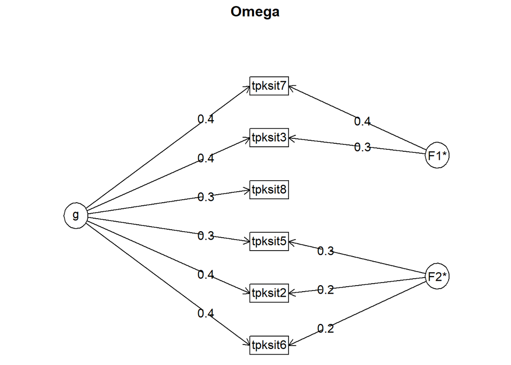

```
Omega
Call: omegah(m = m, nfactors = nfactors, fm = fm, key = key, flip = flip,
    digits = digits, title = title, sl = sl, labels = labels,
    plot = plot, n.obs = n.obs, rotate = rotate, Phi = Phi, option = option,
    covar = covar)
Alpha:                 0.56
G.6:                   0.52
Omega Hierarchical:    0.43
Omega H asymptotic:    0.73
Omega Total            0.59

Schmid Leiman Factor loadings greater than  0.2
           g   F1*   F2*   h2   u2   p2
tpksit2 0.39        0.22 0.21 0.79 0.71
tpksit3 0.37  0.28       0.21 0.79 0.63
tpksit5 0.34        0.33 0.23 0.77 0.51
tpksit6 0.45        0.20 0.28 0.72 0.73
tpksit7 0.39  0.36       0.29 0.71 0.54
tpksit8 0.26             0.09 0.91 0.71

With Sums of squares  of:
   g  F1*  F2*
0.82 0.28 0.21

general/max  2.96   max/min =   1.33
mean percent general =  0.64    with sd =  0.09 and cv of  0.15
Explained Common Variance of the general factor =  0.63

The degrees of freedom are 4  and the fit is  0.01
The number of observations was  670  with Chi Square =  4.61  with prob <  0.33
The root mean square of the residuals is  0.02
The df corrected root mean square of the residuals is  0.03
RMSEA index =  0.015  and the 10 % confidence intervals are  0 0.062
BIC =  -21.42

Compare this with the adequacy of just a general factor and no group factors
The degrees of freedom for just the general factor are 9  and the fit is  0.04
The number of observations was  670  with Chi Square =  24.79  with prob <  0.0032
The root mean square of the residuals is  0.06
The df corrected root mean square of the residuals is  0.07

RMSEA index =  0.051  and the 10 % confidence intervals are  0.028 0.076
BIC =  -33.78

Measures of factor score adequacy
                                                  g   F1*   F2*
Correlation of scores with factors             0.66  0.44  0.40
Multiple R square of scores with factors       0.43  0.19  0.16
Minimum correlation of factor score estimates -0.13 -0.61 -0.68

 Total, General and Subset omega for each subset
                                                 g  F1*  F2*
Omega total for total scores and subscales    0.59 0.41 0.46
Omega general for total scores and subscales  0.43 0.26 0.32
Omega group for total scores and subscales    0.10 0.15 0.13
```

```r
# Omega without the subscale AV
psych::omega(LAA_K4_MZP1%>%dplyr::select(tpksit2,
                                         tpksit3,
                                         #tpksit4,
                                         tpksit5,
                                         tpksit6,
                                         tpksit7,
                                         tpksit8#,
                                         #tpksit10,
                                         #tpksit11,
                                         #tpksit12
                                 ), nfactors = 2)
```

> And can’t be improved by deleting, e.g. a subscale.

**CFAs**

```r
model <- '
          tpk_sit =~ tpksit2 +
                     tpksit3 +
                     tpksit4 +
                     tpksit5 +
                     tpksit6 +
                     tpksit7 +
                     tpksit8 +
                     tpksit10 +
                     tpksit11 +
                     tpksit12
         '

fit <- lavaan::cfa(model, LAA_K4_MZP1)
summary(fit, fit.measures = TRUE)
```

```
lavaan 0.6-18 ended normally after 95 iterations

  Estimator                                         ML
  Optimization method                           NLMINB
  Number of model parameters                        20

  Number of observations                           670

Model Test User Model:

  Test statistic                               130.540
  Degrees of freedom                                35
  P-value (Chi-square)                           0.000

Model Test Baseline Model:

  Test statistic                               539.984
  Degrees of freedom                                45
  P-value                                        0.000

User Model versus Baseline Model:

  Comparative Fit Index (CFI)                    0.807
  Tucker-Lewis Index (TLI)                       0.752

Loglikelihood and Information Criteria:

  Loglikelihood user model (H0)               2824.869
  Loglikelihood unrestricted model (H1)       2890.139

  Akaike (AIC)                               -5609.739
  Bayesian (BIC)                             -5519.593
  Sample-size adjusted Bayesian (SABIC)      -5583.095

Root Mean Square Error of Approximation:

  RMSEA                                          0.064
  90 Percent confidence interval - lower         0.052
  90 Percent confidence interval - upper         0.076
  P-value H_0: RMSEA <= 0.050                    0.025
```

[output cut: 24 more lines]

```
    tpksit12          0.909    0.176    5.152    0.000

Variances:
                   Estimate  Std.Err  z-value  P(>|z|)
   .tpksit2           0.025    0.001   16.877    0.000
   .tpksit3           0.023    0.001   16.548    0.000
   .tpksit4           0.026    0.002   15.790    0.000
   .tpksit5           0.016    0.001   17.234    0.000
   .tpksit6           0.021    0.002   14.052    0.000
   .tpksit7           0.022    0.001   15.944    0.000
   .tpksit8           0.020    0.001   16.741    0.000
   .tpksit10          0.023    0.001   17.035    0.000
   .tpksit11          0.029    0.002   17.247    0.000
   .tpksit12          0.025    0.001   17.097    0.000
    tpk_sit           0.004    0.001    3.741    0.000
```

CFA shows not-so-good fit. But can be greatly improved by deleting the subscale AV.

```r
model <- '
          tpk_sit =~ tpksit2 +
                     tpksit3 +
                     #tpksit4 +
                     tpksit5 +
                     tpksit6 +
                     tpksit7 +
                     tpksit8 #+
                     #tpksit10 +
                     #tpksit11 +
                     #tpksit12
         '

fit <- lavaan::cfa(model, LAA_K4_MZP1)
summary(fit, fit.measures = TRUE)
```

```
lavaan 0.6-18 ended normally after 62 iterations

  Estimator                                         ML
  Optimization method                           NLMINB
  Number of model parameters                        12

  Number of observations                           670

Model Test User Model:

  Test statistic                                12.663
  Degrees of freedom                                 9
  P-value (Chi-square)                           0.178

Model Test Baseline Model:

  Test statistic                               256.592
  Degrees of freedom                                15
  P-value                                        0.000

User Model versus Baseline Model:

  Comparative Fit Index (CFI)                    0.985
  Tucker-Lewis Index (TLI)                       0.975

Loglikelihood and Information Criteria:

  Loglikelihood user model (H0)               1816.519
  Loglikelihood unrestricted model (H1)       1822.850

  Akaike (AIC)                               -3609.037
  Bayesian (BIC)                             -3554.950
  Sample-size adjusted Bayesian (SABIC)      -3593.051

Root Mean Square Error of Approximation:

  RMSEA                                          0.025
  90 Percent confidence interval - lower         0.000
  90 Percent confidence interval - upper         0.053
  P-value H_0: RMSEA <= 0.050                    0.921
```

[output cut: 16 more lines]

```
    tpksit3           0.949    0.152    6.254    0.000
    tpksit5           0.617    0.111    5.560    0.000
    tpksit6           1.208    0.180    6.696    0.000
    tpksit7           0.958    0.151    6.331    0.000
    tpksit8           0.614    0.120    5.126    0.000

Variances:
                   Estimate  Std.Err  z-value  P(>|z|)
   .tpksit2           0.023    0.002   14.869    0.000
   .tpksit3           0.022    0.001   15.109    0.000
   .tpksit5           0.016    0.001   16.408    0.000
   .tpksit6           0.021    0.002   12.924    0.000
   .tpksit7           0.021    0.001   14.879    0.000
   .tpksit8           0.021    0.001   16.877    0.000
    tpk_sit           0.006    0.001    4.471    0.000
```

**ALK**

Same works with ALK, there, also the reliability is improved.

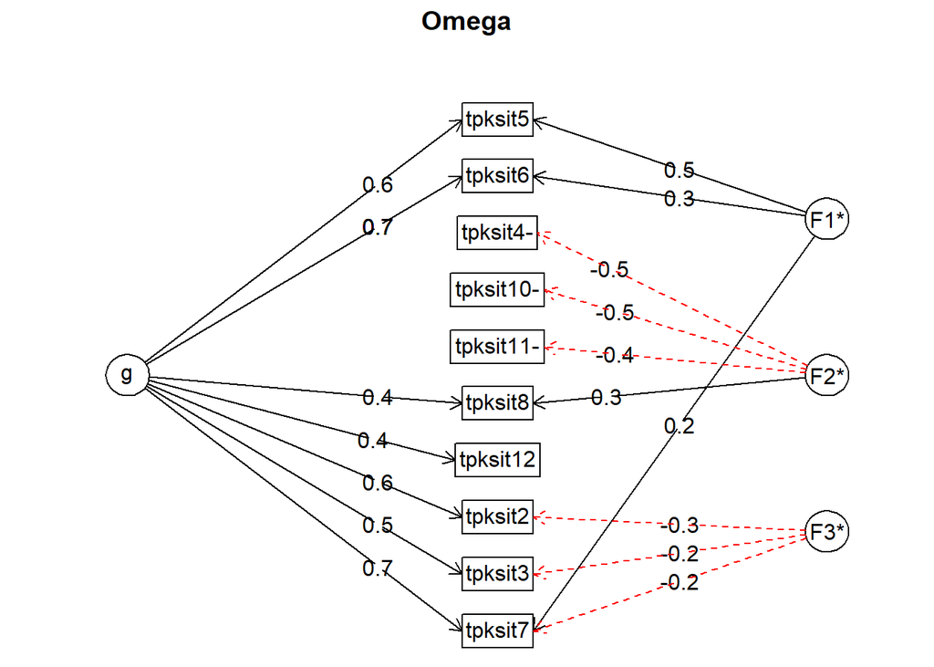

```
Omega
Call: omegah(m = m, nfactors = nfactors, fm = fm, key = key, flip = flip,
    digits = digits, title = title, sl = sl, labels = labels,
    plot = plot, n.obs = n.obs, rotate = rotate, Phi = Phi, option = option,
    covar = covar)
Alpha:                 0.7
G.6:                   0.72
Omega Hierarchical:    0.6
Omega H asymptotic:    0.78
Omega Total            0.77

Schmid Leiman Factor loadings greater than  0.2
              g   F1*   F2*   F3*   h2   u2   p2
tpksit2    0.55             -0.34 0.42 0.58 0.72
tpksit3    0.53             -0.24 0.35 0.65 0.81
tpksit4-              -0.54       0.29 0.71 0.00
tpksit5    0.60  0.47             0.59 0.41 0.62
tpksit6    0.68  0.32             0.60 0.40 0.76
tpksit7    0.67  0.21       -0.22 0.55 0.45 0.82
tpksit8    0.37        0.25       0.23 0.77 0.61
tpksit10-             -0.48       0.25 0.75 0.00
tpksit11-             -0.36       0.18 0.82 0.10
tpksit12   0.42                   0.24 0.76 0.74

With Sums of squares  of:
   g  F1*  F2*  F3*
2.20 0.45 0.77 0.28

general/max  2.86   max/min =   2.75
mean percent general =  0.52    with sd =  0.34 and cv of  0.66
Explained Common Variance of the general factor =  0.59

The degrees of freedom are 18  and the fit is  0.03
The number of observations was  658  with Chi Square =  21.35  with prob <  0.26
The root mean square of the residuals is  0.02
The df corrected root mean square of the residuals is  0.02
RMSEA index =  0.017  and the 10 % confidence intervals are  0 0.04
BIC =  -95.45

Compare this with the adequacy of just a general factor and no group factors
The degrees of freedom for just the general factor are 35  and the fit is  0.33
The number of observations was  658  with Chi Square =  213.44  with prob <  1.8e-27
The root mean square of the residuals is  0.08
The df corrected root mean square of the residuals is  0.1

RMSEA index =  0.088  and the 10 % confidence intervals are  0.077 0.1
BIC =  -13.68

Measures of factor score adequacy
                                                 g   F1*  F2*   F3*
Correlation of scores with factors            0.83  0.54 0.71  0.42
Multiple R square of scores with factors      0.69  0.29 0.51  0.18
Minimum correlation of factor score estimates 0.38 -0.41 0.02 -0.64

 Total, General and Subset omega for each subset
                                                 g  F1*  F2*  F3*
Omega total for total scores and subscales    0.77 0.73 0.31 0.68
Omega general for total scores and subscales  0.60 0.53 0.15 0.56
Omega group for total scores and subscales    0.08 0.20 0.15 0.12
```

```r
psych::omega(ALK_K4_MZP1%>%dplyr::select(tpksit2:tpksit12), nfactors = 3)
```

Reliability is meh.

Weakest items are `tpksit4`, `tpksit10` and , `tpksit11`. They are all from the subscale AV. If we delete one more item (`tpksit12`) we could delete the entire subscale.

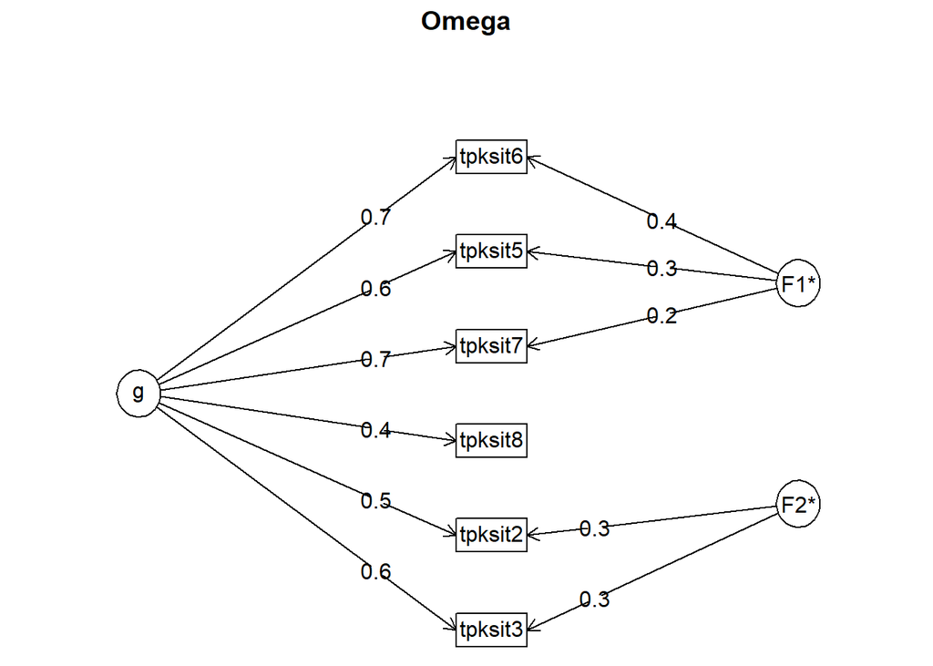

```
Omega
Call: omegah(m = m, nfactors = nfactors, fm = fm, key = key, flip = flip,
    digits = digits, title = title, sl = sl, labels = labels,
    plot = plot, n.obs = n.obs, rotate = rotate, Phi = Phi, option = option,
    covar = covar)
Alpha:                 0.79
G.6:                   0.77
Omega Hierarchical:    0.71
Omega H asymptotic:    0.87
Omega Total            0.81

Schmid Leiman Factor loadings greater than  0.2
           g   F1*   F2*   h2   u2   p2
tpksit2 0.55        0.29 0.38 0.62 0.78
tpksit3 0.57        0.29 0.40 0.60 0.79
tpksit5 0.60  0.26       0.43 0.57 0.83
tpksit6 0.74  0.42       0.71 0.29 0.76
tpksit7 0.69  0.22       0.54 0.46 0.87
tpksit8 0.38             0.17 0.83 0.85

With Sums of squares  of:
   g  F1*  F2*
2.13 0.31 0.19

general/max  6.79   max/min =   1.63
mean percent general =  0.81    with sd =  0.04 and cv of  0.05
Explained Common Variance of the general factor =  0.81

The degrees of freedom are 4  and the fit is  0
The number of observations was  658  with Chi Square =  1.19  with prob <  0.88
The root mean square of the residuals is  0.01
The df corrected root mean square of the residuals is  0.01
RMSEA index =  0  and the 10 % confidence intervals are  0 0.029
BIC =  -24.77

Compare this with the adequacy of just a general factor and no group factors
The degrees of freedom for just the general factor are 9  and the fit is  0.06
The number of observations was  658  with Chi Square =  40.81  with prob <  5.4e-06
The root mean square of the residuals is  0.05
The df corrected root mean square of the residuals is  0.07

RMSEA index =  0.073  and the 10 % confidence intervals are  0.051 0.097
BIC =  -17.59

Measures of factor score adequacy
                                                 g   F1*   F2*
Correlation of scores with factors            0.85  0.48  0.42
Multiple R square of scores with factors      0.73  0.23  0.17
Minimum correlation of factor score estimates 0.46 -0.54 -0.65

 Total, General and Subset omega for each subset
                                                 g  F1*  F2*
Omega total for total scores and subscales    0.81 0.76 0.56
Omega general for total scores and subscales  0.71 0.64 0.44
Omega group for total scores and subscales    0.08 0.12 0.12
```

```r
# Omega without the subscale AV
psych::omega(ALK_K4_MZP1%>%dplyr::select(tpksit2,
                                 tpksit3,
                                 #tpksit4,
                                 tpksit5,
                                 tpksit6,
                                 tpksit7,
                                 tpksit8#,
                                 #tpksit10,
                                 #tpksit11,
                                 #tpksit12
                                 ), nfactors = 2)
```

```r
model <- '
          tpk_sit =~ tpksit2 +
                     tpksit3 +
                     #tpksit4 +
                     tpksit5 +
                     tpksit6 +
                     tpksit7 +
                     tpksit8 #+
                     #tpksit10 +
                     #tpksit11 +
                     #tpksit12
         '

fit <- lavaan::cfa(model, ALK_K4_MZP1)
summary(fit, fit.measures = TRUE)
```

```
lavaan 0.6-18 ended normally after 56 iterations

  Estimator                                         ML
  Optimization method                           NLMINB
  Number of model parameters                        12

  Number of observations                           658

Model Test User Model:

  Test statistic                                20.301
  Degrees of freedom                                 9
  P-value (Chi-square)                           0.016

Model Test Baseline Model:

  Test statistic                              1026.459
  Degrees of freedom                                15
  P-value                                        0.000

User Model versus Baseline Model:

  Comparative Fit Index (CFI)                    0.989
  Tucker-Lewis Index (TLI)                       0.981

Loglikelihood and Information Criteria:

  Loglikelihood user model (H0)               2265.741
  Loglikelihood unrestricted model (H1)       2275.891

  Akaike (AIC)                               -4507.482
  Bayesian (BIC)                             -4453.611
  Sample-size adjusted Bayesian (SABIC)      -4491.711

Root Mean Square Error of Approximation:

  RMSEA                                          0.044
  90 Percent confidence interval - lower         0.018
  90 Percent confidence interval - upper         0.069
  P-value H_0: RMSEA <= 0.050                    0.621
```

[output cut: 16 more lines]

```
    tpksit3           1.062    0.099   10.767    0.000
    tpksit5           1.288    0.109   11.854    0.000
    tpksit6           1.649    0.128   12.897    0.000
    tpksit7           1.468    0.116   12.649    0.000
    tpksit8           0.622    0.072    8.583    0.000

Variances:
                   Estimate  Std.Err  z-value  P(>|z|)
   .tpksit2           0.016    0.001   16.510    0.000
   .tpksit3           0.017    0.001   16.318    0.000
   .tpksit5           0.015    0.001   15.100    0.000
   .tpksit6           0.012    0.001   11.673    0.000
   .tpksit7           0.012    0.001   13.022    0.000
   .tpksit8           0.013    0.001   17.344    0.000
    tpk_sit           0.007    0.001    6.890    0.000
```

**SAB**

Same works with SAB, there, also the reliability is improved.

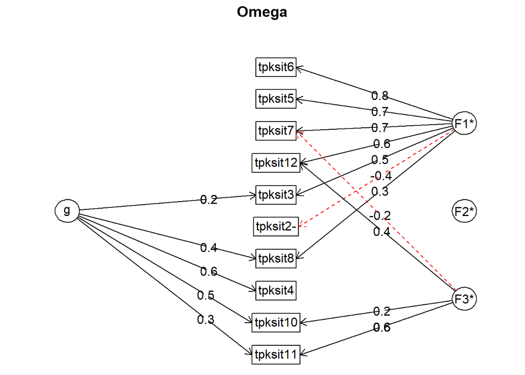

```
Omega
Call: omegah(m = m, nfactors = nfactors, fm = fm, key = key, flip = flip,
    digits = digits, title = title, sl = sl, labels = labels,
    plot = plot, n.obs = n.obs, rotate = rotate, Phi = Phi, option = option,
    covar = covar)
Alpha:                 0.6
G.6:                   0.68
Omega Hierarchical:    0.26
Omega H asymptotic:    0.36
Omega Total            0.73

Schmid Leiman Factor loadings greater than  0.2
            g   F1* F2*   F3*   h2   u2   p2
tpksit2-      -0.44           0.25 0.75 0.00
tpksit3  0.25  0.47           0.31 0.69 0.20
tpksit4  0.57                 0.33 0.67 0.99
tpksit5        0.72           0.59 0.41 0.00
tpksit6        0.80           0.65 0.35 0.03
tpksit7        0.69     -0.21 0.57 0.43 0.03
tpksit8  0.35  0.35           0.25 0.75 0.49
tpksit10 0.51            0.23 0.32 0.68 0.83
tpksit11 0.30            0.63 0.52 0.48 0.17
tpksit12       0.59      0.36 0.43 0.57 0.02

With Sums of squares  of:
   g  F1*  F2*  F3*
0.91 2.53 0.00 0.72

general/max  0.36   max/min =   Inf
mean percent general =  0.28    with sd =  0.37 and cv of  1.33
Explained Common Variance of the general factor =  0.22

The degrees of freedom are 18  and the fit is  0.14
The number of observations was  200  with Chi Square =  26.24  with prob <  0.094
The root mean square of the residuals is  0.03
The df corrected root mean square of the residuals is  0.05
RMSEA index =  0.048  and the 10 % confidence intervals are  0 0.085
BIC =  -69.13

Compare this with the adequacy of just a general factor and no group factors
The degrees of freedom for just the general factor are 35  and the fit is  2.05
The number of observations was  200  with Chi Square =  398.38  with prob <  3.4e-63
The root mean square of the residuals is  0.25
The df corrected root mean square of the residuals is  0.29

RMSEA index =  0.228  and the 10 % confidence intervals are  0.209 0.249
BIC =  212.94

Measures of factor score adequacy
                                                 g  F1* F2*  F3*
Correlation of scores with factors            0.72 0.91   0 0.74
Multiple R square of scores with factors      0.53 0.84   0 0.55
Minimum correlation of factor score estimates 0.05 0.67  -1 0.11

 Total, General and Subset omega for each subset
                                                 g  F1* F2*  F3*
Omega total for total scores and subscales    0.73 0.73  NA 0.53
Omega general for total scores and subscales  0.26 0.14  NA 0.25
Omega group for total scores and subscales    0.51 0.59  NA 0.28
```

```r
psych::omega(SAB_K4_MZP1%>%dplyr::select(tpksit2:tpksit12), nfactors = 3)
```

Reliability is meh.

If we delete the subscale AV:

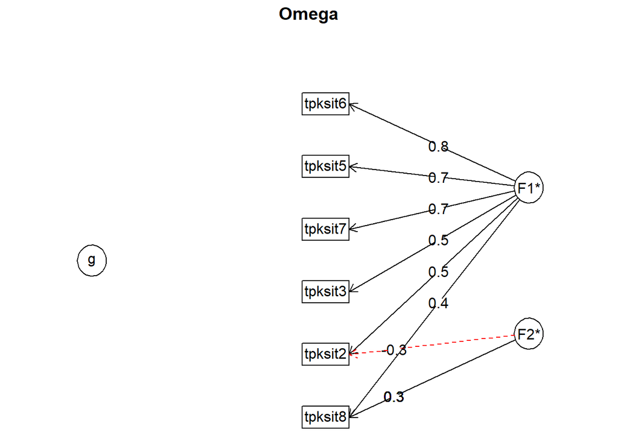

```
Omega
Call: omegah(m = m, nfactors = nfactors, fm = fm, key = key, flip = flip,
    digits = digits, title = title, sl = sl, labels = labels,
    plot = plot, n.obs = n.obs, rotate = rotate, Phi = Phi, option = option,
    covar = covar)
Alpha:                 0.77
G.6:                   0.76
Omega Hierarchical:    0.04
Omega H asymptotic:    0.05
Omega Total            0.8

Schmid Leiman Factor loadings greater than  0.2
            g  F1*   F2*   h2   u2   p2
tpksit2       0.48 -0.31 0.36 0.64 0.09
tpksit3       0.51       0.28 0.72 0.06
tpksit5  0.20 0.73       0.60 0.40 0.06
tpksit6       0.76       0.61 0.39 0.03
tpksit7       0.71       0.53 0.47 0.04
tpksit8       0.40  0.31 0.25 0.75 0.00

With Sums of squares  of:
   g  F1*  F2*
0.12 2.26 0.25

general/max  0.05   max/min =   9.17
mean percent general =  0.05    with sd =  0.03 and cv of  0.66
Explained Common Variance of the general factor =  0.05

The degrees of freedom are 4  and the fit is  0.03
The number of observations was  200  with Chi Square =  5.75  with prob <  0.22
The root mean square of the residuals is  0.02
The df corrected root mean square of the residuals is  0.05
RMSEA index =  0.047  and the 10 % confidence intervals are  0 0.125
BIC =  -15.44

Compare this with the adequacy of just a general factor and no group factors
The degrees of freedom for just the general factor are 9  and the fit is  1.36
The number of observations was  200  with Chi Square =  266.02  with prob <  4.1e-52
The root mean square of the residuals is  0.37
The df corrected root mean square of the residuals is  0.47

RMSEA index =  0.378  and the 10 % confidence intervals are  0.34 0.419
BIC =  218.34

Measures of factor score adequacy
                                                  g  F1*   F2*
Correlation of scores with factors             0.23 0.89  0.53
Multiple R square of scores with factors       0.05 0.79  0.29
Minimum correlation of factor score estimates -0.90 0.59 -0.43

 Total, General and Subset omega for each subset
                                                 g  F1* F2*
Omega total for total scores and subscales    0.80 0.80  NA
Omega general for total scores and subscales  0.04 0.04  NA
Omega group for total scores and subscales    0.76 0.76  NA
```

```r
# Omega without the subscale AV
psych::omega(SAB_K4_MZP1%>%dplyr::select(tpksit2,
                                 tpksit3,
                                 #tpksit4,
                                 tpksit5,
                                 tpksit6,
                                 tpksit7,
                                 tpksit8#,
                                 #tpksit10,
                                 #tpksit11,
                                 #tpksit12
                                 ), nfactors = 2)
```

This model also delivers good fit.

```r
model <- '
          tpk_sit =~ tpksit2 +
                     tpksit3 +
                     #tpksit4 +
                     tpksit5 +
                     tpksit6 +
                     tpksit7 +
                     tpksit8 #+
                     #tpksit10 +
                     #tpksit11 +
                     #tpksit12
         '

fit <- lavaan::cfa(model, SAB_K4_MZP1)
summary(fit, fit.measures = TRUE)
```

```
lavaan 0.6-18 ended normally after 56 iterations

  Estimator                                         ML
  Optimization method                           NLMINB
  Number of model parameters                        12

  Number of observations                           200

Model Test User Model:

  Test statistic                                14.491
  Degrees of freedom                                 9
  P-value (Chi-square)                           0.106

Model Test Baseline Model:

  Test statistic                               310.570
  Degrees of freedom                                15
  P-value                                        0.000

User Model versus Baseline Model:

  Comparative Fit Index (CFI)                    0.981
  Tucker-Lewis Index (TLI)                       0.969

Loglikelihood and Information Criteria:

  Loglikelihood user model (H0)                649.494
  Loglikelihood unrestricted model (H1)        656.740

  Akaike (AIC)                               -1274.989
  Bayesian (BIC)                             -1235.409
  Sample-size adjusted Bayesian (SABIC)      -1273.426

Root Mean Square Error of Approximation:

  RMSEA                                          0.055
  90 Percent confidence interval - lower         0.000
  90 Percent confidence interval - upper         0.105
  P-value H_0: RMSEA <= 0.050                    0.382
```

[output cut: 16 more lines]

```
    tpksit3           1.092    0.210    5.205    0.000
    tpksit5           1.634    0.258    6.338    0.000
    tpksit6           1.823    0.288    6.337    0.000
    tpksit7           1.697    0.273    6.207    0.000
    tpksit8           0.762    0.183    4.175    0.000

Variances:
                   Estimate  Std.Err  z-value  P(>|z|)
   .tpksit2           0.017    0.002    9.324    0.000
   .tpksit3           0.018    0.002    9.228    0.000
   .tpksit5           0.010    0.001    6.877    0.000
   .tpksit6           0.013    0.002    6.883    0.000
   .tpksit7           0.014    0.002    7.592    0.000
   .tpksit8           0.019    0.002    9.656    0.000
    tpk_sit           0.005    0.002    3.369    0.001
```

**My recommendation**

(from a statistical point of view)

- Note: Maybe the measurement models are not equal over the groups?
- We can improve fit greatly, when deleting the subscale AV
- We should first check if there are Items that seem “old” and check if deleting them would improve reliability and fit
  - I feel like the only item building on “dated” concepts is item 1, which isn’t part of any scale anyway

# 3 Con-Factor

**Reliability**

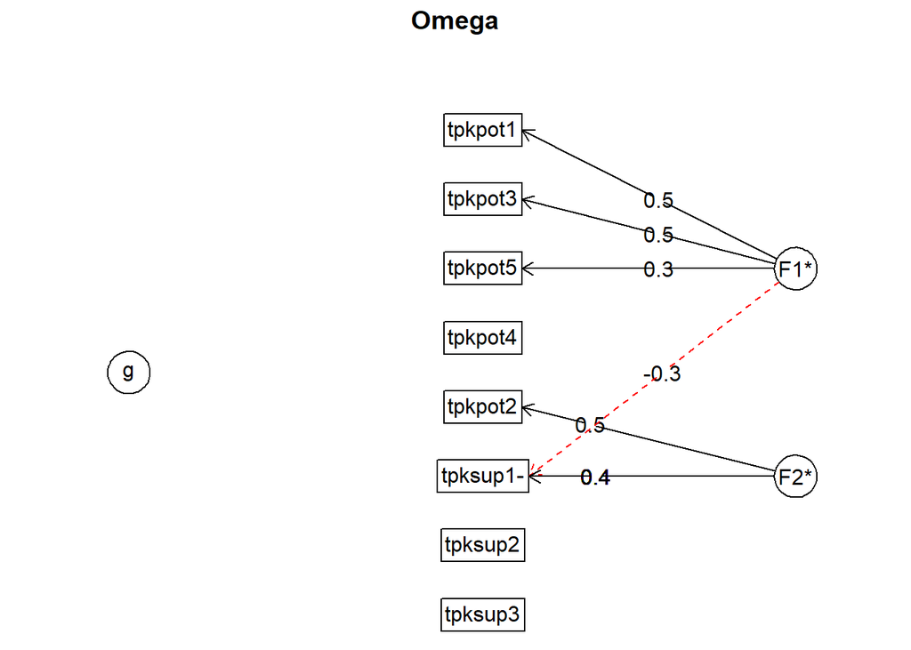

```
Omega
Call: omegah(m = m, nfactors = nfactors, fm = fm, key = key, flip = flip,
    digits = digits, title = title, sl = sl, labels = labels,
    plot = plot, n.obs = n.obs, rotate = rotate, Phi = Phi, option = option,
    covar = covar)
Alpha:                 0.3
G.6:                   0.29
Omega Hierarchical:    0.03
Omega H asymptotic:    0.1
Omega Total            0.36

Schmid Leiman Factor loadings greater than  0.2
             g   F1*   F2*   h2   u2   p2
tpkpot1         0.46       0.24 0.76 0.07
tpkpot2               0.45 0.26 0.74 0.09
tpkpot3         0.45       0.21 0.79 0.06
tpkpot4                    0.05 0.95 0.09
tpkpot5         0.25       0.07 0.93 0.04
tpksup1-       -0.29  0.38 0.23 0.77 0.00
tpksup2                    0.05 0.95 0.10
tpksup3                    0.01 0.99 0.09

With Sums of squares  of:
   g  F1*  F2*
0.06 0.65 0.39

general/max  0.1   max/min =   1.66
mean percent general =  0.07    with sd =  0.03 and cv of  0.5
Explained Common Variance of the general factor =  0.06

The degrees of freedom are 13  and the fit is  0.02
The number of observations was  670  with Chi Square =  13.61  with prob <  0.4
The root mean square of the residuals is  0.02
The df corrected root mean square of the residuals is  0.04
RMSEA index =  0.008  and the 10 % confidence intervals are  0 0.04
BIC =  -70.99

Compare this with the adequacy of just a general factor and no group factors
The degrees of freedom for just the general factor are 20  and the fit is  0.19
The number of observations was  670  with Chi Square =  123.4  with prob <  6.7e-17
The root mean square of the residuals is  0.09
The df corrected root mean square of the residuals is  0.1

RMSEA index =  0.088  and the 10 % confidence intervals are  0.073 0.103
BIC =  -6.74

Measures of factor score adequacy
                                                  g   F1*   F2*
Correlation of scores with factors             0.21  0.66  0.58
Multiple R square of scores with factors       0.04  0.44  0.33
Minimum correlation of factor score estimates -0.91 -0.12 -0.34

 Total, General and Subset omega for each subset
                                                 g  F1*  F2*
Omega total for total scores and subscales    0.36 0.36 0.26
Omega general for total scores and subscales  0.03 0.02 0.01
Omega group for total scores and subscales    0.27 0.34 0.24
```

```r
psych::omega(LAA_K4_MZP1%>%dplyr::select(tpkpot1:tpksup3), nfactors = 2)
```

> Reliability is not good.

```r
# Omega without the subscale AV
psych::omega(LAA_K4_MZP1%>%dplyr::select(tpkpot1,
                                         tpkpot2,
                                         tpkpot3,
                                         #tpkpot4,
                                         tpkpot5#,
                                         # tpksup1,
                                         #tpksup2#,
                                         # tpksup3
                                 ), nfactors = 1)
```

```
Omega
Call: omegah(m = m, nfactors = nfactors, fm = fm, key = key, flip = flip,
    digits = digits, title = title, sl = sl, labels = labels,
    plot = plot, n.obs = n.obs, rotate = rotate, Phi = Phi, option = option,
    covar = covar)
Alpha:                 0.35
G.6:                   0.3
Omega Hierarchical:    0.38
Omega H asymptotic:    1.01
Omega Total            0.37

Schmid Leiman Factor loadings greater than  0.2
           g  F1*   h2   u2 p2
tpkpot1 0.53      0.28 0.72  1
tpkpot2 0.25      0.06 0.94  1
tpkpot3 0.45      0.20 0.80  1
tpkpot5 0.20      0.04 0.96  1

With Sums of squares  of:
   g  F1*
0.59 0.00

general/max  8.437365e+15   max/min =   1
mean percent general =  1    with sd =  0 and cv of  0
Explained Common Variance of the general factor =  1

The degrees of freedom are 2  and the fit is  0.01
The number of observations was  670  with Chi Square =  5.42  with prob <  0.067
The root mean square of the residuals is  0.03
The df corrected root mean square of the residuals is  0.06
RMSEA index =  0.051  and the 10 % confidence intervals are  0 0.104
BIC =  -7.59

Compare this with the adequacy of just a general factor and no group factors
The degrees of freedom for just the general factor are 2  and the fit is  0.01
The number of observations was  670  with Chi Square =  5.42  with prob <  0.067
The root mean square of the residuals is  0.03
The df corrected root mean square of the residuals is  0.06

RMSEA index =  0.051  and the 10 % confidence intervals are  0 0.104
BIC =  -7.59

Measures of factor score adequacy
                                                  g F1*
Correlation of scores with factors             0.66   0
Multiple R square of scores with factors       0.43   0
Minimum correlation of factor score estimates -0.14  -1

 Total, General and Subset omega for each subset
                                                 g  F1*
Omega total for total scores and subscales    0.37 0.38
Omega general for total scores and subscales  0.38 0.38
Omega group for total scores and subscales    0.00 0.00
```

> And can’t be improved by deleting, e.g. a subscale.

**CFAs**

```r
model <- '
          tpk_con =~ tpkpot1 +
                     tpkpot2 +
                     tpkpot3 +
                     tpkpot4 +
                     tpkpot5 +
                     tpksup1 +
                     tpksup2 +
                     tpksup3
         '

fit <- lavaan::cfa(model, LAA_K4_MZP1)
summary(fit, fit.measures = TRUE)
```

```
lavaan 0.6-18 ended normally after 73 iterations

  Estimator                                         ML
  Optimization method                           NLMINB
  Number of model parameters                        16

  Number of observations                           670

Model Test User Model:

  Test statistic                                44.836
  Degrees of freedom                                20
  P-value (Chi-square)                           0.001

Model Test Baseline Model:

  Test statistic                               141.381
  Degrees of freedom                                28
  P-value                                        0.000

User Model versus Baseline Model:

  Comparative Fit Index (CFI)                    0.781
  Tucker-Lewis Index (TLI)                       0.693

Loglikelihood and Information Criteria:

  Loglikelihood user model (H0)                552.315
  Loglikelihood unrestricted model (H1)        574.733

  Akaike (AIC)                               -1072.630
  Bayesian (BIC)                             -1000.514
  Sample-size adjusted Bayesian (SABIC)      -1051.315

Root Mean Square Error of Approximation:

  RMSEA                                          0.043
  90 Percent confidence interval - lower         0.026
  90 Percent confidence interval - upper         0.060
  P-value H_0: RMSEA <= 0.050                    0.731
```

[output cut: 20 more lines]

```
    tpksup1           0.366    0.131    2.787    0.005
    tpksup2           0.270    0.107    2.538    0.011
    tpksup3           0.105    0.111    0.945    0.345

Variances:
                   Estimate  Std.Err  z-value  P(>|z|)
   .tpkpot1           0.036    0.003   10.370    0.000
   .tpkpot2           0.060    0.003   17.149    0.000
   .tpkpot3           0.034    0.003   11.345    0.000
   .tpkpot4           0.056    0.003   17.332    0.000
   .tpkpot5           0.048    0.003   16.893    0.000
   .tpksup1           0.049    0.003   17.582    0.000
   .tpksup2           0.034    0.002   17.735    0.000
   .tpksup3           0.044    0.002   18.237    0.000
    tpk_con           0.012    0.003    3.570    0.000
```

CFA shows fit concerning CFI and TLI is not good. But can be greatly improved by deleting the subscale `sup` and item `tpkpot4` from the `pot` subscale.

```r
model <- '
          tpk_con =~ tpkpot1 +
                     tpkpot2 +
                     tpkpot3 +
                     #tpkpot4 +
                     tpkpot5 #+
                     #tpksup1 +
                     #tpksup2 +
                     #tpksup3
         '

fit <- lavaan::cfa(model, LAA_K4_MZP1)
summary(fit, fit.measures = TRUE)
```

```
lavaan 0.6-18 ended normally after 40 iterations

  Estimator                                         ML
  Optimization method                           NLMINB
  Number of model parameters                         8

  Number of observations                           670

Model Test User Model:

  Test statistic                                 5.429
  Degrees of freedom                                 2
  P-value (Chi-square)                           0.066

Model Test Baseline Model:

  Test statistic                                72.183
  Degrees of freedom                                 6
  P-value                                        0.000

User Model versus Baseline Model:

  Comparative Fit Index (CFI)                    0.948
  Tucker-Lewis Index (TLI)                       0.845

Loglikelihood and Information Criteria:

  Loglikelihood user model (H0)                220.156
  Loglikelihood unrestricted model (H1)        222.871

  Akaike (AIC)                                -424.313
  Bayesian (BIC)                              -388.255
  Sample-size adjusted Bayesian (SABIC)       -413.655

Root Mean Square Error of Approximation:

  RMSEA                                          0.051
  90 Percent confidence interval - lower         0.000
  90 Percent confidence interval - upper         0.104
  P-value H_0: RMSEA <= 0.050                    0.402
```

[output cut: 12 more lines]

```
Latent Variables:
                   Estimate  Std.Err  z-value  P(>|z|)
  tpk_con =~
    tpkpot1           1.000
    tpkpot2           0.542    0.174    3.114    0.002
    tpkpot3           0.785    0.247    3.179    0.001
    tpkpot5           0.383    0.141    2.716    0.007

Variances:
                   Estimate  Std.Err  z-value  P(>|z|)
   .tpkpot1           0.034    0.005    7.129    0.000
   .tpkpot2           0.059    0.004   16.514    0.000
   .tpkpot3           0.035    0.003   10.470    0.000
   .tpkpot5           0.049    0.003   17.271    0.000
    tpk_con           0.014    0.005    2.877    0.004
```

**ALK**

Same works with ALK, there, also the reliability is improved.

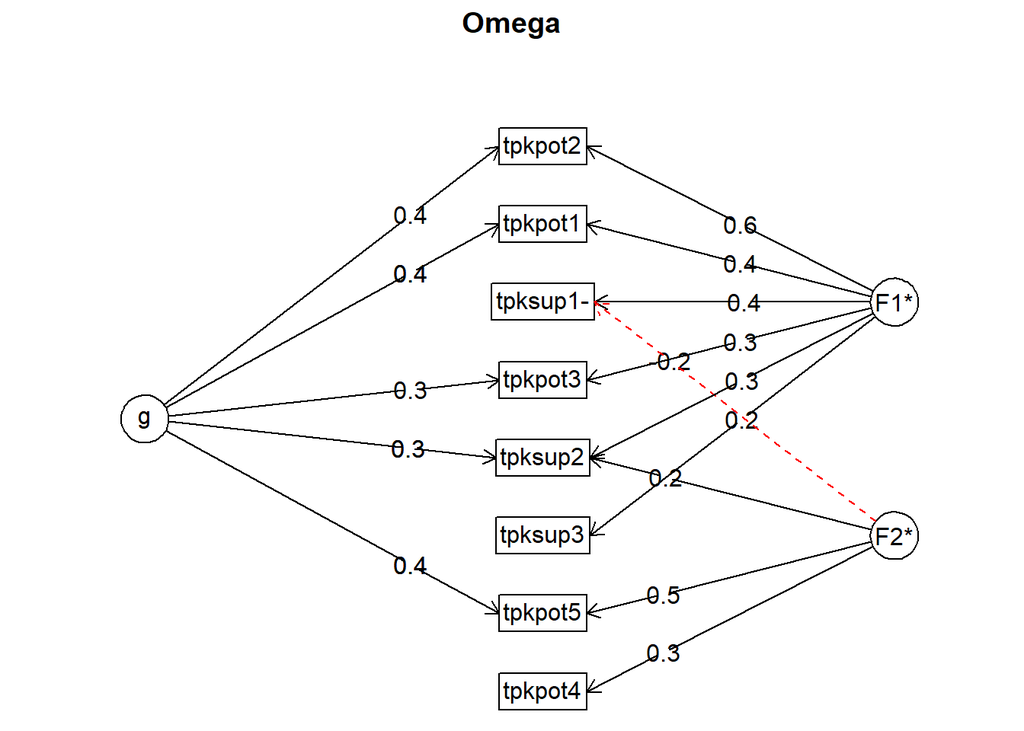

```
Omega
Call: omegah(m = m, nfactors = nfactors, fm = fm, key = key, flip = flip,
    digits = digits, title = title, sl = sl, labels = labels,
    plot = plot, n.obs = n.obs, rotate = rotate, Phi = Phi, option = option,
    covar = covar)
Alpha:                 0.58
G.6:                   0.59
Omega Hierarchical:    0.29
Omega H asymptotic:    0.46
Omega Total            0.64

Schmid Leiman Factor loadings greater than  0.2
             g   F1*   F2*   h2   u2   p2
tpkpot1   0.35  0.40       0.29 0.71 0.42
tpkpot2   0.45  0.64       0.60 0.40 0.33
tpkpot3   0.29  0.26       0.17 0.83 0.47
tpkpot4               0.31 0.13 0.87 0.19
tpkpot5   0.39        0.51 0.41 0.59 0.36
tpksup1-        0.37 -0.22 0.20 0.80 0.06
tpksup2   0.32  0.26  0.21 0.21 0.79 0.48
tpksup3         0.25       0.08 0.92 0.19

With Sums of squares  of:
   g  F1*  F2*
0.71 0.90 0.49

general/max  0.78   max/min =   1.83
mean percent general =  0.31    with sd =  0.15 and cv of  0.48
Explained Common Variance of the general factor =  0.34

The degrees of freedom are 13  and the fit is  0.09
The number of observations was  658  with Chi Square =  60.53  with prob <  4.2e-08
The root mean square of the residuals is  0.04
The df corrected root mean square of the residuals is  0.06
RMSEA index =  0.075  and the 10 % confidence intervals are  0.056 0.094
BIC =  -23.83

Compare this with the adequacy of just a general factor and no group factors
The degrees of freedom for just the general factor are 20  and the fit is  0.38
The number of observations was  658  with Chi Square =  248.77  with prob <  2e-41
The root mean square of the residuals is  0.12
The df corrected root mean square of the residuals is  0.14

RMSEA index =  0.132  and the 10 % confidence intervals are  0.118 0.147
BIC =  118.98

Measures of factor score adequacy
                                                  g   F1*   F2*
Correlation of scores with factors             0.58  0.70  0.60
Multiple R square of scores with factors       0.34  0.49  0.36
Minimum correlation of factor score estimates -0.33 -0.01 -0.28

 Total, General and Subset omega for each subset
                                                 g  F1*  F2*
Omega total for total scores and subscales    0.64 0.62 0.40
Omega general for total scores and subscales  0.29 0.22 0.12
Omega group for total scores and subscales    0.33 0.40 0.28
```

```r
psych::omega(ALK_K4_MZP1%>%dplyr::select(tpkpot1:tpksup3), nfactors = 2)
```

Can be improved, deleting the subscale `sup` and item `tpkpot4` from the `pot` subscale.

```r
# Omega without the subscale AV
psych::omega(ALK_K4_MZP1%>%dplyr::select(tpkpot1,
                                         tpkpot2,
                                         tpkpot3,
                                         #tpkpot4,
                                         tpkpot5#,
                                         #tpksup1,
                                         #tpksup2,
                                         #tpksup3
                                 ), nfactors = 1)
```

```
Omega
Call: omegah(m = m, nfactors = nfactors, fm = fm, key = key, flip = flip,
    digits = digits, title = title, sl = sl, labels = labels,
    plot = plot, n.obs = n.obs, rotate = rotate, Phi = Phi, option = option,
    covar = covar)
Alpha:                 0.59
G.6:                   0.53
Omega Hierarchical:    0.6
Omega H asymptotic:    1
Omega Total            0.6

Schmid Leiman Factor loadings greater than  0.2
           g  F1*   h2   u2 p2
tpkpot1 0.70      0.48 0.52  1
tpkpot2 0.59      0.35 0.65  1
tpkpot3 0.43      0.19 0.81  1
tpkpot5 0.36      0.13 0.87  1

With Sums of squares  of:
  g F1*
1.1 0.0

general/max  1.03292e+16   max/min =   1
mean percent general =  1    with sd =  0 and cv of  0
Explained Common Variance of the general factor =  1

The degrees of freedom are 2  and the fit is  0.01
The number of observations was  658  with Chi Square =  6.1  with prob <  0.047
The root mean square of the residuals is  0.03
The df corrected root mean square of the residuals is  0.05
RMSEA index =  0.056  and the 10 % confidence intervals are  0.005 0.109
BIC =  -6.88

Compare this with the adequacy of just a general factor and no group factors
The degrees of freedom for just the general factor are 2  and the fit is  0.01
The number of observations was  658  with Chi Square =  6.1  with prob <  0.047
The root mean square of the residuals is  0.03
The df corrected root mean square of the residuals is  0.05

RMSEA index =  0.056  and the 10 % confidence intervals are  0.005 0.109
BIC =  -6.88

Measures of factor score adequacy
                                                 g F1*
Correlation of scores with factors            0.81   0
Multiple R square of scores with factors      0.65   0
Minimum correlation of factor score estimates 0.30  -1

 Total, General and Subset omega for each subset
                                                g F1*
Omega total for total scores and subscales    0.6 0.6
Omega general for total scores and subscales  0.6 0.6
Omega group for total scores and subscales    0.0 0.0
```

This model also delivers good fit.

```r
model <- '
          tpk_con =~ tpkpot1 +
                     tpkpot2 +
                     tpkpot3 +
                     #tpkpot4 +
                     tpkpot5 #+
                     #tpksup1 +
                     #tpksup2 +
                     #tpksup3
         '

fit <- lavaan::cfa(model, ALK_K4_MZP1)
summary(fit, fit.measures = TRUE)
```

```
lavaan 0.6-18 ended normally after 37 iterations

  Estimator                                         ML
  Optimization method                           NLMINB
  Number of model parameters                         8

  Number of observations                           658

Model Test User Model:

  Test statistic                                 6.052
  Degrees of freedom                                 2
  P-value (Chi-square)                           0.049

Model Test Baseline Model:

  Test statistic                               260.946
  Degrees of freedom                                 6
  P-value                                        0.000

User Model versus Baseline Model:

  Comparative Fit Index (CFI)                    0.984
  Tucker-Lewis Index (TLI)                       0.952

Loglikelihood and Information Criteria:

  Loglikelihood user model (H0)                697.414
  Loglikelihood unrestricted model (H1)        700.440

  Akaike (AIC)                               -1378.829
  Bayesian (BIC)                             -1342.915
  Sample-size adjusted Bayesian (SABIC)      -1368.315

Root Mean Square Error of Approximation:

  RMSEA                                          0.055
  90 Percent confidence interval - lower         0.004
  90 Percent confidence interval - upper         0.109
  P-value H_0: RMSEA <= 0.050                    0.344
```

[output cut: 12 more lines]

```
Latent Variables:
                   Estimate  Std.Err  z-value  P(>|z|)
  tpk_con =~
    tpkpot1           1.000
    tpkpot2           1.130    0.144    7.851    0.000
    tpkpot3           0.534    0.074    7.237    0.000
    tpkpot5           0.427    0.068    6.289    0.000

Variances:
                   Estimate  Std.Err  z-value  P(>|z|)
   .tpkpot1           0.019    0.002    7.757    0.000
   .tpkpot2           0.045    0.004   11.731    0.000
   .tpkpot3           0.023    0.001   15.740    0.000
   .tpkpot5           0.025    0.001   16.733    0.000
    tpk_con           0.019    0.003    6.517    0.000
```

**SAB**

Same works with SAB, there, also the reliability is improved.

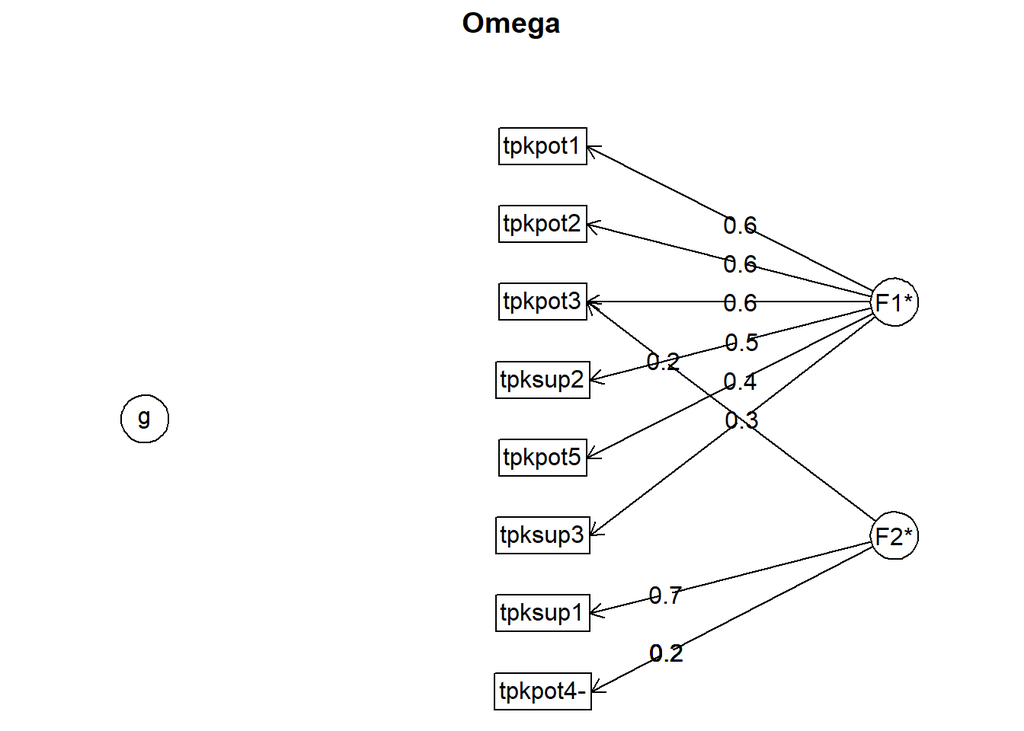

```
Omega
Call: omegah(m = m, nfactors = nfactors, fm = fm, key = key, flip = flip,
    digits = digits, title = title, sl = sl, labels = labels,
    plot = plot, n.obs = n.obs, rotate = rotate, Phi = Phi, option = option,
    covar = covar)
Alpha:                 0.52
G.6:                   0.55
Omega Hierarchical:    0
Omega H asymptotic:    0
Omega Total            0.61

Schmid Leiman Factor loadings greater than  0.2
             g   F1*   F2*   h2   u2 p2
tpkpot1         0.61       0.38 0.62  0
tpkpot2         0.58       0.36 0.64  0
tpkpot3         0.56  0.23 0.36 0.64  0
tpkpot4-              0.25 0.07 0.93  0
tpkpot5         0.39       0.15 0.85  0
tpksup1               0.74 0.55 0.45  0
tpksup2         0.53       0.30 0.70  0
tpksup3         0.31       0.12 0.88  0

With Sums of squares  of:
   g  F1*  F2*
0.00 1.57 0.71

general/max  0   max/min =   2.21
mean percent general =  0    with sd =  0 and cv of  NaN
Explained Common Variance of the general factor =  0

The degrees of freedom are 13  and the fit is  0.07
The number of observations was  200  with Chi Square =  14.52  with prob <  0.34
The root mean square of the residuals is  0.04
The df corrected root mean square of the residuals is  0.05
RMSEA index =  0.024  and the 10 % confidence intervals are  0 0.076
BIC =  -54.36

Compare this with the adequacy of just a general factor and no group factors
The degrees of freedom for just the general factor are 20  and the fit is  0.86
The number of observations was  200  with Chi Square =  167.86  with prob <  2.3e-25
The root mean square of the residuals is  0.2
The df corrected root mean square of the residuals is  0.24

RMSEA index =  0.192  and the 10 % confidence intervals are  0.166 0.22
BIC =  61.89

Measures of factor score adequacy
                                                  g  F1*  F2*
Correlation of scores with factors             0.02 0.84 0.77
Multiple R square of scores with factors       0.00 0.70 0.59
Minimum correlation of factor score estimates -1.00 0.40 0.17

 Total, General and Subset omega for each subset
                                                 g  F1*  F2*
Omega total for total scores and subscales    0.61 0.67 0.41
Omega general for total scores and subscales  0.00 0.00 0.00
Omega group for total scores and subscales    0.67 0.67 0.41
```

```r
psych::omega(SAB_K4_MZP1%>%dplyr::select(tpkpot1:tpksup3), nfactors = 2)
```

Reliability is meh.

```r
# Omega without the subscale AV
psych::omega(SAB_K4_MZP1%>%dplyr::select(tpkpot1,
                                         tpkpot2,
                                         tpkpot3,
                                         #tpkpot4,
                                         tpkpot5#,
                                         #tpksup1,
                                         #tpksup2,
                                         #tpksup3
                                 ), nfactors = 1)
```

```
Omega
Call: omegah(m = m, nfactors = nfactors, fm = fm, key = key, flip = flip,
    digits = digits, title = title, sl = sl, labels = labels,
    plot = plot, n.obs = n.obs, rotate = rotate, Phi = Phi, option = option,
    covar = covar)
Alpha:                 0.61
G.6:                   0.55
Omega Hierarchical:    0.62
Omega H asymptotic:    1
Omega Total            0.62

Schmid Leiman Factor loadings greater than  0.2
           g  F1*   h2   u2 p2
tpkpot1 0.61      0.38 0.62  1
tpkpot2 0.59      0.35 0.65  1
tpkpot3 0.57      0.32 0.68  1
tpkpot5 0.36      0.13 0.87  1

With Sums of squares  of:
  g F1*
1.2 0.0

general/max  1.415997e+16   max/min =   1
mean percent general =  1    with sd =  0 and cv of  0
Explained Common Variance of the general factor =  1

The degrees of freedom are 2  and the fit is  0.01
The number of observations was  200  with Chi Square =  1.85  with prob <  0.4
The root mean square of the residuals is  0.03
The df corrected root mean square of the residuals is  0.05
RMSEA index =  0  and the 10 % confidence intervals are  0 0.137
BIC =  -8.75

Compare this with the adequacy of just a general factor and no group factors
The degrees of freedom for just the general factor are 2  and the fit is  0.01
The number of observations was  200  with Chi Square =  1.85  with prob <  0.4
The root mean square of the residuals is  0.03
The df corrected root mean square of the residuals is  0.05

RMSEA index =  0  and the 10 % confidence intervals are  0 0.137
BIC =  -8.75

Measures of factor score adequacy
                                                 g F1*
Correlation of scores with factors            0.80   0
Multiple R square of scores with factors      0.64   0
Minimum correlation of factor score estimates 0.28  -1

 Total, General and Subset omega for each subset
                                                 g  F1*
Omega total for total scores and subscales    0.62 0.62
Omega general for total scores and subscales  0.62 0.62
Omega group for total scores and subscales    0.00 0.00
```

This model also delivers good fit.

```r
model <- '
          tpk_con =~ tpkpot1 +
                     tpkpot2 +
                     tpkpot3 +
                     # tpkpot4 +
                     tpkpot5 #+
                     # tpksup1 +
                     # tpksup2 +
                     # tpksup3
         '

fit <- lavaan::cfa(model, SAB_K4_MZP1)
summary(fit, fit.measures = TRUE)
```

```
lavaan 0.6-18 ended normally after 41 iterations

  Estimator                                         ML
  Optimization method                           NLMINB
  Number of model parameters                         8

  Number of observations                           200

Model Test User Model:

  Test statistic                                 1.869
  Degrees of freedom                                 2
  P-value (Chi-square)                           0.393

Model Test Baseline Model:

  Test statistic                                84.635
  Degrees of freedom                                 6
  P-value                                        0.000

User Model versus Baseline Model:

  Comparative Fit Index (CFI)                    1.000
  Tucker-Lewis Index (TLI)                       1.005

Loglikelihood and Information Criteria:

  Loglikelihood user model (H0)                148.791
  Loglikelihood unrestricted model (H1)        149.726

  Akaike (AIC)                                -281.583
  Bayesian (BIC)                              -255.196
  Sample-size adjusted Bayesian (SABIC)       -280.541

Root Mean Square Error of Approximation:

  RMSEA                                          0.000
  90 Percent confidence interval - lower         0.000
  90 Percent confidence interval - upper         0.137
  P-value H_0: RMSEA <= 0.050                    0.554
```

[output cut: 12 more lines]

```
Latent Variables:
                   Estimate  Std.Err  z-value  P(>|z|)
  tpk_con =~
    tpkpot1           1.000
    tpkpot2           1.517    0.323    4.691    0.000
    tpkpot3           0.964    0.207    4.668    0.000
    tpkpot5           0.626    0.176    3.559    0.000

Variances:
                   Estimate  Std.Err  z-value  P(>|z|)
   .tpkpot1           0.022    0.003    6.421    0.000
   .tpkpot2           0.052    0.008    6.556    0.000
   .tpkpot3           0.025    0.004    7.148    0.000
   .tpkpot5           0.034    0.004    9.162    0.000
    tpk_con           0.013    0.004    3.425    0.001
```

**My recommendation**

(from a statistical point of view)

- Note: Maybe the measurement models are not equal over the groups?
- We can improve fit greatly, when deleting the subscale `sub` and item `tpkpot4` from subscale `pot`
- We should first check if there are Items that seem “old” and check if deleting them would improve reliability and fit
  - …

# 4 Computational environment

## 4.1 Packages

```r
installed.packages()[names(sessionInfo()$otherPkgs), "Version"]
```

```
      rio      here     psych    lavaan lubridate   forcats   stringr     dplyr
  "1.0.1"   "1.0.1"   "2.4.3"  "0.6-18"   "1.9.3"   "1.0.0"   "1.5.1"   "1.1.4"
    purrr     readr     tidyr    tibble   ggplot2 tidyverse
  "1.0.2"   "2.1.4"   "1.3.1"   "3.2.1"   "3.5.1"   "2.0.0"
```

## 4.2 R Version

```r
R.Version()
```

```
$platform
[1] "x86_64-w64-mingw32"

$arch
[1] "x86_64"

$os
[1] "mingw32"

$crt
[1] "ucrt"

$system
[1] "x86_64, mingw32"

$status
[1] ""

$major
[1] "4"

$minor
[1] "3.3"

$year
[1] "2024"

$month
[1] "02"

$day
[1] "29"

$`svn rev`
[1] "86002"

$language
[1] "R"

$version.string
[1] "R version 4.3.3 (2024-02-29 ucrt)"

$nickname
[1] "Angel Food Cake"
```